# Final Project

John Frederickson

4/2/2022

# Analysis of Non-Voter Data

## Introduction

For my final project, I will be doing an analysis of Non-Voter data, from FiveThirtyEight’s non-voter data set. I will first perform an analysis of the basic variables in order to draw preliminary insight as which influence someones likelihood to vote. I will then split the model into two sets, a training set (80%) and a testing set (20%), and create a preliminary prediction model. Then the full data set will be examined, starting with AOV tests to determine which variables are significant. A larger prediction model will be fitted on every variable, and reduced models will be created through VIF backwards elimination. Finally these models will all be compared, and the best model of them will be chosen.

### Background Information

In the last election I did not receive a ballot before election day, despite having an accurate up to date voter registration and address. During the process of finding a time and place to vote, I wondered whether it was worth it or not, and if my vote actually made a difference. Being a student and having the time I was able to vote, though experiences such as my own are extremely common. Thousands if not millions of U.S. citizens have similar experiences every year, and along with many other factors result in an extremely low turnout of eligible voters. In any given presidential election, the U.S. experiences a voter turnout of roughly 55% of the voting population voting and 60% of voting age citizens voting (Pew Research). This figure places the U.S. among the worst voter turnout rates of developed countries. When this project was assigned I went looking for data sets covering a wide variety of topics, and I stumbled across FiverThirtyEight’s non-voter data set. After exploring the code book and general information, I was determined to use it for my final project.

### About the Data Set

Data Set Link: https://github.com/fivethirtyeight/data/tree/master/non-voters

Basic information was collected such as income, gender, education, weight, race, and age as well as how often they vote. Each participants were put into one of three categories, never or rarely vote (voted in 0 or 1 elections), sometimes vote (more than 1, less than all but 1), and nearly always vote (voted in all or all but one election), based on how often they have voted in elections they are eligible for. Each respondent was also asked a variety of other questions, such as their political affiliation, their preferred method of voting, their plans for the 2020 election, whether their vote matters, their trust in government, barriers to voting, and whether or not the government needs change. Many of these questions were split up into sub questions, such as trust in specific parts of the government, and have multiple levels for each (A lot, some, not much, not at all, etc).

### Initial Setup

```r
# Load data set
vote <- read.csv("https://raw.githubusercontent.com/fivethirtyeight/data/master/non-voters/nonvoters_data.csv")

# Load libraries
library(dplyr)
```

```r
library(ggplot2)
library(MASS)
library(car)
library(caTools)
library(corrplot)
library(caret)
library(cvms)
library(cowplot)
```

#### Recoding variables

Before analysis can begin, some data cleaning must be performed. Firstly, voter categories to a numeric variable and assign it to a new variable called voteChance. This will be useful later to examine and compare means across levels of the factor variables. The vast majority of the columns contain factor variables, which are recoded from numbers to the worded response (Such as agree, disagree, etc) to simplify interpretation of the results. The rest of the variables are recoded from their numeric factor values (used to reduce the size of the data set file) into their corresponding worded responses. Out of the data set a few variables were left out, as they relied on the answer of another variable, or were mostly filled with “No Response”. This included questions 19 (and its 10 associated sub-questions, Q19_1…Q19_10), 22, 27 (As it was used to create the response variable), 28, 29, 31, 32, and 33. Following the data cleaning, it is then separated into training (80%) and testing (20%) sets.

Voter Category Levels: always -> 3, sporadic -> 2, never -> 1

```r
vote$voteChance <- as.numeric(recode_factor(vote$voter_category, "rarely/never" = 1, "sporadic" = 2, "always" = 3))

vote$voter_category = factor(vote$voter_category, levels = c("rarely/never", "sporadic", "always"), ordered = TRUE)

vote$income_cat <- as.factor(vote$income_cat)

vote$educ <- as.factor(vote$educ)

vote$gender <- as.factor(vote$gender)

vote$race <- as.factor(vote$race)

vote$Q2_1 <- factor(vote$Q2_1)
vote$Q2_1 <- recode_factor(vote$Q2_1, "1" = "Very Important", "2" = "Somewhat Important", "3" = "Not Very Important", "4" = "Not at all Important", "-1" = "No Response")

vote$Q2_2 <- factor(vote$Q2_2)
vote$Q2_2 <- recode_factor(vote$Q2_2, "1" = "Very Important", "2" = "Somewhat Important", "3" = "Not Very Important", "4" = "Not at all Important", "-1" = "No Response")

vote$Q2_3 <- factor(vote$Q2_3)
vote$Q2_3 <- recode_factor(vote$Q2_3, "1" = "Very Important", "2" = "Somewhat Important", "3" = "Not Very Important", "4" = "Not at all Important", "-1" = "No Response")

vote$Q2_4 <- factor(vote$Q2_4)
vote$Q2_4 <- recode_factor(vote$Q2_4, "1" = "Very Important", "2" = "Somewhat Important", "3" = "Not Very Important", "4" = "Not at all Important", "-1" = "No Response")

vote$Q2_5 <- factor(vote$Q2_5)
vote$Q2_5 <- recode_factor(vote$Q2_5, "1" = "Very Important", "2" = "Somewhat Important", "3" = "Not Very Important", "4" = "Not at all Important", "-1" = "No Response")

vote$Q2_6 <- factor(vote$Q2_6)
vote$Q2_6 <- recode_factor(vote$Q2_6, "1" = "Very Important", "2" = "Somewhat Important", "3" = "Not Very Important", "4" = "Not at all Important", "-1" = "No Response")

vote$Q2_7 <- factor(vote$Q2_7)
vote$Q2_7 <- recode_factor(vote$Q2_7, "1" = "Very Important", "2" = "Somewhat Important", "3" = "Not Very Important", "4" = "Not at all Important", "-1" = "No Response")

vote$Q2_8 <- factor(vote$Q2_8)
vote$Q2_8 <- recode_factor(vote$Q2_8, "1" = "Very Important", "2" = "Somewhat Important", "3" = "Not Very Important", "4" = "Not at all Important", "-1" = "No Response")

vote$Q2_9 <- factor(vote$Q2_9)
vote$Q2_9 <- recode_factor(vote$Q2_9, "1" = "Very Important", "2" = "Somewhat Important", "3" = "Not Very Important", "4" = "Not at all Important", "-1" = "No Response")

vote$Q2_10 <- factor(vote$Q2_10)
vote$Q2_10 <- recode_factor(vote$Q2_10, "1" = "Very Important", "2" = "Somewhat Important", "3" = "Not Very Important", "4" = "Not at all Important", "-1" = "No Response")

vote$Q3_1 <- factor(vote$Q3_1)
vote$Q3_1 <- recode_factor(vote$Q3_1, "1" = "Strongly Agree", "2" = "Somewhat Agree", "3" = "Somewhat Disagree", "4" = "Strongly Disagree", "-1" = "No Response")

vote$Q3_2 <- factor(vote$Q3_2)
vote$Q3_2 <- recode_factor(vote$Q3_2, "1" = "Strongly Agree", "2" = "Somewhat Agree", "3" = "Somewhat Disagree", "4" = "Strongly Disagree", "-1" = "No Response")

vote$Q3_3 <- factor(vote$Q3_3)
vote$Q3_3 <- recode_factor(vote$Q3_3, "1" = "Strongly Agree", "2" = "Somewhat Agree", "3" = "Somewhat Disagree", "4" = "Strongly Disagree", "-1" = "No Response")

vote$Q3_4 <- factor(vote$Q3_4)
vote$Q3_4 <- recode_factor(vote$Q3_4, "1" = "Strongly Agree", "2" = "Somewhat Agree", "3" = "Somewhat Disagree", "4" = "Strongly Disagree", "-1" = "No Response")

vote$Q3_5 <- factor(vote$Q3_5)
vote$Q3_5 <- recode_factor(vote$Q3_5, "1" = "Strongly Agree", "2" = "Somewhat Agree", "3" = "Somewhat Disagree", "4" = "Strongly Disagree", "-1" = "No Response")

vote$Q3_6 <- factor(vote$Q3_6)
vote$Q3_6 <- recode_factor(vote$Q3_6, "1" = "Strongly Agree", "2" = "Somewhat Agree", "3" = "Somewhat Disagree", "4" = "Strongly Disagree", "-1" = "No Response")

vote$Q4_1 <- factor(vote$Q4_1)
vote$Q4_1 <- recode_factor(vote$Q4_1, "1" = "Significant", "2" = "Somewhat", "3" = "Slight", "4" = "None", "-1" = "No Response")

vote$Q4_2 <- factor(vote$Q4_2)
vote$Q4_2 <- recode_factor(vote$Q4_2, "1" = "Significant", "2" = "Somewhat", "3" = "Slight", "4" = "None", "-1" = "No Response")

vote$Q4_3 <- factor(vote$Q4_3)
vote$Q4_3 <- recode_factor(vote$Q4_3, "1" = "Significant", "2" = "Somewhat", "3" = "Slight", "4" = "None", "-1" = "No Response")

vote$Q4_4 <- factor(vote$Q4_4)
vote$Q4_4 <- recode_factor(vote$Q4_4, "1" = "Significant", "2" = "Somewhat", "3" = "Slight", "4" = "None", "-1" = "No Response")

vote$Q4_5 <- factor(vote$Q4_5)
vote$Q4_5 <- recode_factor(vote$Q4_5, "1" = "Significant", "2" = "Somewhat", "3" = "Slight", "4" = "None", "-1" = "No Response")

vote$Q4_6 <- factor(vote$Q4_6)
vote$Q4_6 <- recode_factor(vote$Q4_6, "1" = "Significant", "2" = "Somewhat", "3" = "Slight", "4" = "None", "-1" = "No Response")

vote$Q5 <- factor(vote$Q5)
vote$Q5 <- recode_factor(vote$Q5, "1" = "2020 Matters", "2" = "2020 Doesn't Matter", "-1" = "No Response")

vote$Q6 <- factor(vote$Q6)
vote$Q6 <- recode_factor(vote$Q6, "1" = "A lot", "2" = "Some", "3" = "A few", "4" = "None", "-1" = "No Response")

vote$Q7 <- factor(vote$Q7)
vote$Q7 <- recode_factor(vote$Q7, "1" = "Changes Needed", "2" = "Changes Not Needed", "-1" = "No Response")

vote$Q8_1 <- factor(vote$Q8_1)
vote$Q8_1 <- recode_factor(vote$Q8_1, "1" = "A lot", "2" = "Some", "3" = "Not much", "4" = "Not at all", "-1" = "No Response")

vote$Q8_2 <- factor(vote$Q8_2)
vote$Q8_2 <- recode_factor(vote$Q8_2, "1" = "A lot", "2" = "Some", "3" = "Not much", "4" = "Not at all", "-1" = "No Response")

vote$Q8_3 <- factor(vote$Q8_3)
vote$Q8_3 <- recode_factor(vote$Q8_3, "1" = "A lot", "2" = "Some", "3" = "Not much", "4" = "Not at all", "-1" = "No Response")

vote$Q8_4 <- factor(vote$Q8_4)
vote$Q8_4 <- recode_factor(vote$Q8_4, "1" = "A lot", "2" = "Some", "3" = "Not much", "4" = "Not at all", "-1" = "No Response")

vote$Q8_5 <- factor(vote$Q8_5)
vote$Q8_5 <- recode_factor(vote$Q8_5, "1" = "A lot", "2" = "Some", "3" = "Not much", "4" = "Not at all", "-1" = "No Response")

vote$Q8_6 <- factor(vote$Q8_6)
vote$Q8_6 <- recode_factor(vote$Q8_6, "1" = "A lot", "2" = "Some", "3" = "Not much", "4" = "Not at all", "-1" = "No Response")

vote$Q8_7 <- factor(vote$Q8_7)
vote$Q8_7 <- recode_factor(vote$Q8_7, "1" = "A lot", "2" = "Some", "3" = "Not much", "4" = "Not at all", "-1" = "No Response")

vote$Q8_8 <- factor(vote$Q8_8)
vote$Q8_8 <- recode_factor(vote$Q8_8, "1" = "A lot", "2" = "Some", "3" = "Not much", "4" = "Not at all", "-1" = "No Response")

vote$Q8_9 <- factor(vote$Q8_9)
vote$Q8_9 <- recode_factor(vote$Q8_9, "1" = "A lot", "2" = "Some", "3" = "Not much", "4" = "Not at all", "-1" = "No Response")

vote$Q9_1 <- factor(vote$Q9_1)
vote$Q9_1 <- recode_factor(vote$Q9_1, "1" = "Very Good", "2" = "Fairly Good", "3" = "Fairly Bad", "4" = "Very Bad", "-1" = "No Response")

vote$Q9_2 <- factor(vote$Q9_2)
vote$Q9_2 <- recode_factor(vote$Q9_2, "1" = "Very Good", "2" = "Fairly Good", "3" = "Fairly Bad", "4" = "Very Bad", "-1" = "No Response")

vote$Q9_3 <- factor(vote$Q9_3)
vote$Q9_3 <- recode_factor(vote$Q9_3, "1" = "Very Good", "2" = "Fairly Good", "3" = "Fairly Bad", "4" = "Very Bad", "-1" = "No Response")

vote$Q9_4 <- factor(vote$Q9_4)
vote$Q9_4 <- recode_factor(vote$Q9_4, "1" = "Very Good", "2" = "Fairly Good", "3" = "Fairly Bad", "4" = "Very Bad", "-1" = "No Response")

vote$Q10_1 <- factor(vote$Q10_1)
vote$Q10_1 <- recode_factor(vote$Q10_1, "1" = "Yes", "2" = "No", "-1" = "No Response")

vote$Q10_2 <- factor(vote$Q10_2)
vote$Q10_2 <- recode_factor(vote$Q10_2, "1" = "Yes", "2" = "No", "-1" = "No Response")

vote$Q10_3 <- factor(vote$Q10_3)
vote$Q10_3 <- recode_factor(vote$Q10_3, "1" = "Yes", "2" = "No", "-1" = "No Response")

vote$Q10_4 <- factor(vote$Q10_4)
vote$Q10_4 <- recode_factor(vote$Q10_4, "1" = "Yes", "2" = "No", "-1" = "No Response")

vote$Q11_1 <- factor(vote$Q11_1)
vote$Q11_1 <- recode_factor(vote$Q11_1, "1" = "Yes", "2" = "No", "-1" = "No Response")

vote$Q11_2 <- factor(vote$Q11_2)
vote$Q11_2 <- recode_factor(vote$Q11_2, "1" = "Yes", "2" = "No", "-1" = "No Response")

vote$Q11_3 <- factor(vote$Q11_3)
vote$Q11_3 <- recode_factor(vote$Q11_3, "1" = "Yes", "2" = "No", "-1" = "No Response")

vote$Q11_4 <- factor(vote$Q11_4)
vote$Q11_4 <- recode_factor(vote$Q11_4, "1" = "Yes", "2" = "No", "-1" = "No Response")

vote$Q11_5 <- factor(vote$Q11_5)
vote$Q11_5 <- recode_factor(vote$Q11_5, "1" = "Yes", "2" = "No", "-1" = "No Response")

vote$Q11_6 <- factor(vote$Q11_6)
vote$Q11_6 <- recode_factor(vote$Q11_6, "1" = "Yes", "2" = "No", "-1" = "No Response")

vote$Q14 <- factor(vote$Q14)

vote$Q15 <- factor(vote$Q15)

vote$Q16 <- factor(vote$Q16)
vote$Q16 <- recode_factor(vote$Q16, "1" = "Very Easy", "2" = "Somewhat Easy", "3" = "Somewhat Difficult", "4" = "Very Difficult", "-1" = "No Response")

vote$Q17_1 <- factor(vote$Q17_1)
vote$Q17_1 <- recode_factor(vote$Q17_1, "1" = "Very Confident", "2" = "Somewhat Confident", "3" = "Not Very Confident", "4" = "Not at all Confident", "-1" = "No Response")

vote$Q17_2 <- factor(vote$Q17_2)
vote$Q17_2 <- recode_factor(vote$Q17_2, "1" = "Very Confident", "2" = "Somewhat Confident", "3" = "Not Very Confident", "4" = "Not at all Confident", "-1" = "No Response")

vote$Q17_3 <- factor(vote$Q17_3)
vote$Q17_3 <- recode_factor(vote$Q17_3, "1" = "Very Confident", "2" = "Somewhat Confident", "3" = "Not Very Confident", "4" = "Not at all Confident", "-1" = "No Response")

vote$Q17_4 <- factor(vote$Q17_4)
vote$Q17_4 <- recode_factor(vote$Q17_4, "1" = "Very Confident", "2" = "Somewhat Confident", "3" = "Not Very Confident", "4" = "Not at all Confident", "-1" = "No Response")

vote$Q18_1 <- factor(vote$Q18_1)
vote$Q18_1 <- recode_factor(vote$Q18_1, "1" = "Yes", "2" = "No", "-1" = "No Response")

vote$Q18_2 <- factor(vote$Q18_2)
vote$Q18_2 <- recode_factor(vote$Q18_2, "1" = "Yes", "2" = "No", "-1" = "No Response")

vote$Q18_3 <- factor(vote$Q18_3)
vote$Q18_3 <- recode_factor(vote$Q18_3, "1" = "Yes", "2" = "No", "-1" = "No Response")

vote$Q18_4 <- factor(vote$Q18_4)
vote$Q18_4 <- recode_factor(vote$Q18_4, "1" = "Yes", "2" = "No", "-1" = "No Response")

vote$Q18_5 <- factor(vote$Q18_5)
vote$Q18_5 <- recode_factor(vote$Q18_5, "1" = "Yes", "2" = "No", "-1" = "No Response")

vote$Q18_6 <- factor(vote$Q18_6)
vote$Q18_6 <- recode_factor(vote$Q18_6, "1" = "Yes", "2" = "No", "-1" = "No Response")

vote$Q18_7 <- factor(vote$Q18_7)
vote$Q18_7 <- recode_factor(vote$Q18_7, "1" = "Yes", "2" = "No", "-1" = "No Response")

vote$Q18_8 <- factor(vote$Q18_8)
vote$Q18_8 <- recode_factor(vote$Q18_8, "1" = "Yes", "2" = "No", "-1" = "No Response")

vote$Q18_9 <- factor(vote$Q18_9)
vote$Q18_9 <- recode_factor(vote$Q18_9, "1" = "Yes", "2" = "No", "-1" = "No Response")

vote$Q18_10 <- factor(vote$Q18_10)
vote$Q18_10 <- recode_factor(vote$Q18_10, "1" = "Yes", "2" = "No", "-1" = "No Response")

vote$Q20 <- factor(vote$Q20)
vote$Q20 <- recode_factor(vote$Q20, "1" = "Yes", "2" = "No", "-1" = "No Response")

vote$Q21 <- factor(vote$Q21)
vote$Q21 <- recode_factor(vote$Q21, "1" = "Yes", "2" = "No", "3" = "Undecided", "-1" = "No Response")

vote$Q23 <- factor(vote$Q23)
vote$Q23 <- recode_factor(vote$Q23, "1" = "Donald Trump", "2" = "Joe Biden", "3" = "Unsure", "-1" = "No Response")

vote$Q24 <- factor(vote$Q24)
vote$Q24 <- recode_factor(vote$Q24, "1" = "Mail in", "2" = "In person before elec. day", "3" = "In person on elec. day", "4" = "other", "-1" = "No Response")

vote$Q25 <- factor(vote$Q25)
vote$Q25 <- recode_factor(vote$Q25, "1" = "Very Closely", "2" = "Somewhat Closely", "3" = "Not Very Closely", "4" = "Not at all", "-1" = "No Response")

vote$Q26 <- factor(vote$Q26)
vote$Q26 <- recode_factor(vote$Q26, "1" = "Always", "2" = "Sometimes", "3" = "Rarely", "4" = "Never", "-1" = "No Response")

vote$Q30 <- factor(vote$Q30)
vote$Q30 <- recode_factor(vote$Q30, "1" = "Republican", "2" = "Democrat", "3" = "Independent", "4" = "Other", "5" = "No Preference", "-1" = "No Response")

head(vote)
```

```
##   RespId weight Q1               Q2_1               Q2_2               Q2_3
## 1 470001 0.7516  1     Very Important     Very Important Somewhat Important
## 2 470002 1.0267  1     Very Important Somewhat Important Somewhat Important
## 3 470003 1.0844  1     Very Important     Very Important Somewhat Important
## 4 470007 0.6817  1     Very Important     Very Important     Very Important
## 5 480008 0.9910  1     Very Important     Very Important        No Response
## 6 480009 1.0591  1 Not Very Important Somewhat Important Not Very Important
##                   Q2_4           Q2_5                 Q2_6               Q2_7
## 1 Not at all Important Very Important Not at all Important Somewhat Important
## 2   Not Very Important Very Important       Very Important Somewhat Important
## 3   Somewhat Important Very Important       Very Important Somewhat Important
## 4   Not Very Important Very Important       Very Important     Very Important
## 5       Very Important Very Important       Very Important     Very Important
## 6 Not at all Important Very Important   Not Very Important Not Very Important
##                 Q2_8                 Q2_9                Q2_10
```

[output cut: 104 more lines]

```r
# Generate a random vector to label which rows will be split
set.seed(123456)
split <- sample.split(vote$RespId, SplitRatio = 0.8)

#Split basic set
voteBasic <- vote %>% dplyr::select(educ, race, gender, income_cat, ppage, voter_category, weight, voteChance)
basicTraining <- subset(voteBasic, split == TRUE)
basicTesting  <- subset(voteBasic, split == FALSE)

#Split full set
voteTraining <- subset(vote, split == TRUE)
voteTesting  <- subset(vote, split == FALSE)
```

## Part 1: Basic Variables

The basic variables to be explored are income category, education level, gender, sex, age, and weight. Voter category is the main response variable.

### 1a: Basic Analysis

#### Visualizations of Voter Category Distributions

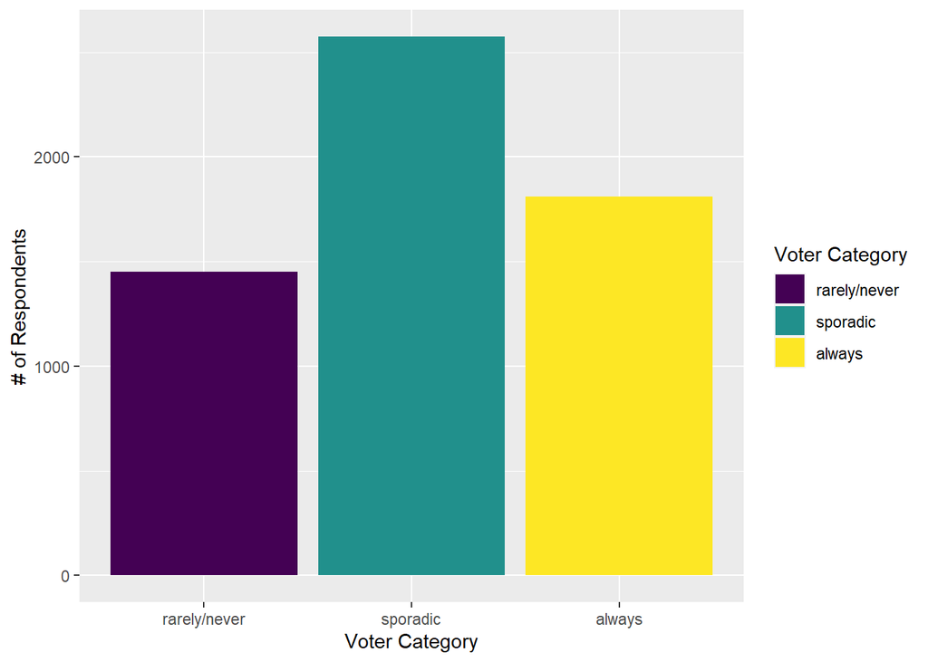

```r
ggplot(vote, aes(x = factor(voter_category, levels = c("rarely/never", "sporadic", "always")), fill = factor(voter_category, levels = c("rarely/never", "sporadic", "always")))) + geom_bar() + xlab("Voter Category") + guides(fill = guide_legend(title = "Voter Category")) + ylab("# of Respondents")
```

The chart above shows the distribution of the voter categories across the surveyed population. The sporadic category contained the most respondents, with the other two categories demonstrating a fairly normal distribution. The data does appear to be a bit skewed towards the right, through it is hard to tell as there are only 3 categories.

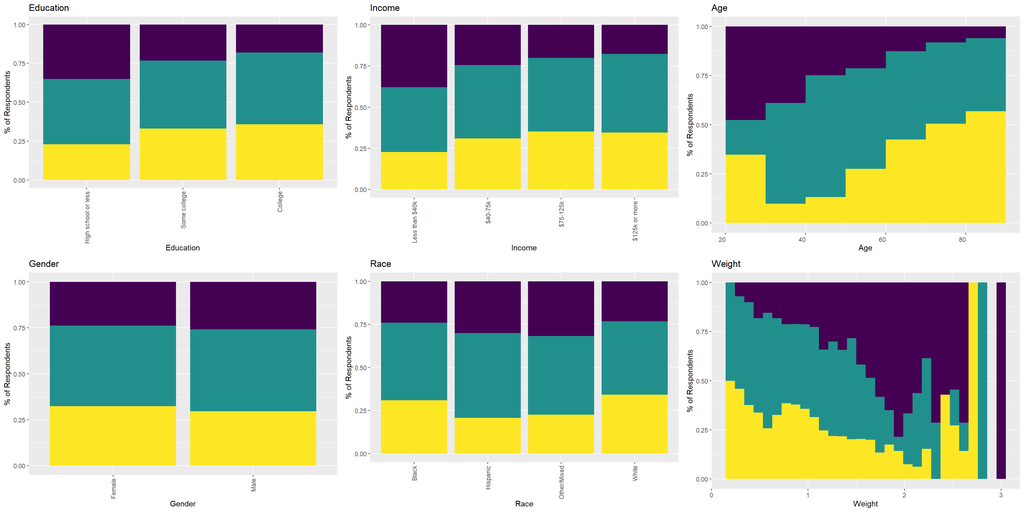

```r
# Remove just the basic variables
voteBasic <- vote %>% dplyr::select(educ, race, gender, income_cat, ppage, voter_category, weight, voteChance)

#Education
basicBar1 <- ggplot(voteBasic, aes(x = factor(educ, levels = c("High school or less", "Some college", "College")), fill = factor(voter_category, levels = c("rarely/never", "sporadic", "always")))) + # Create basic Plot
  geom_bar(position = "fill") +
  xlab("Education") + ylab("% of Respondents") + ggtitle("Education") +# Add axis labels
  guides(fill = guide_legend(title = "Voter Category")) +
  theme(axis.text.x = element_text(angle = 90, vjust = 0.5, hjust=1), legend.position = "none") # Rotate category labels

#Income
basicBar2 <- ggplot(voteBasic, aes(x = factor(income_cat, levels = c("Less than $40k", "$40-75k", "$75-125k", "$125k or more")), fill = factor(voter_category, levels = c("rarely/never", "sporadic", "always")))) + # Create basic Plot
  geom_bar(position = "fill") +
  xlab("Income") + ylab("% of Respondents") + ggtitle("Income") + # Add axis labels
  guides(fill = guide_legend(title = "Voter Category")) +
  theme(axis.text.x = element_text(angle = 90, vjust = 0.5, hjust=1), legend.position="none") # Rotate category labels

#Age
#Note: Age is continuous, use histogram rather than bar plot
basicBar3 <- ggplot(voteBasic, aes(x = ppage, fill = factor(voter_category, levels = c("rarely/never", "sporadic", "always")))) + # Create basic Plot
  geom_histogram(breaks = c(20, 30, 40, 50, 60, 70, 80, 90), position = "fill") +
  xlab("Age") + ylab("% of Respondents") + ggtitle("Age") + # Add axis labels
  guides(fill = guide_legend(title = "Voter Category")) +
  theme(axis.text.x = element_text(angle = 0, vjust = 0.5, hjust=1), legend.position="none") # Rotate category labels

#Gender
basicBar4 <- ggplot(voteBasic, aes(x = gender, fill = factor(voter_category, levels = c("rarely/never", "sporadic", "always")))) + # Create basic Plot
  geom_bar(position = "fill") +
  xlab("Gender") + ylab("% of Respondents") + ggtitle("Gender") + # Add axis labels
  guides(fill = guide_legend(title = "Voter Category")) +
  theme(axis.text.x = element_text(angle = 90, vjust = 0.5, hjust=1), legend.position="none") # Rotate category labels

#Race
basicBar5 <- ggplot(voteBasic, aes(x = race, fill = factor(voter_category, levels = c("rarely/never", "sporadic", "always"))), legend.position="none") + # Create basic Plot
  geom_bar(position = "fill") +
  xlab("Race") + ylab("% of Respondents") + ggtitle("Race") + # Add axis labels
  guides(fill = guide_legend(title = "Voter Category")) +
  theme(axis.text.x = element_text(angle = 90, vjust = 0.5, hjust=1), legend.position="none") # Rotate category labels

#Weight
#Note: Continuous variable, use histogram rather than bar plot
basicBar6 <- ggplot(voteBasic, aes(x = weight, fill = factor(voter_category, levels = c("rarely/never", "sporadic", "always")))) + # Create basic Plot
  geom_histogram(position = "fill") +
  xlab("Weight") + ylab("% of Respondents") + ggtitle("Weight") +# Add axis labels
  guides(fill = guide_legend(title = "Voter Category")) + theme(legend.position="none")

plot_grid(basicBar1, basicBar2, basicBar3, basicBar4, basicBar5, basicBar6)
```

These plots show the distribution of these voter categories across the different basic variables. Education, income, age and weight clearly show a difference in distribution across the different levels. It appears that as education, income, and age increase, the nonvoter category shrinks. Weight shows a reversal of this response, while gender and race do not appear to have much of an affect.

The results of these plots can be quantified with an analysis of variance test (AOV) to determine if there is a statistically significant difference in voter category as the value of the independent variable changes.

```r
educResult <- aov(voteChance ~ educ, data = voteBasic)
summary(educResult)
```

```
##               Df Sum Sq Mean Sq F value Pr(>F)
## educ           2   93.9   46.97   87.09 <2e-16 ***
## Residuals   5833 3145.9    0.54
## ---
## Signif. codes:  0 '***' 0.001 '**' 0.01 '*' 0.05 '.' 0.1 ' ' 1
```

With a P-value less than 0.05, it can be concluded there is some meaningful difference in mean of voter category by different levels of education. This test does not give results of each group however, only that a significant difference does exist across any two groups. The significance of different levels can be examined with the TukeyHSD function.

```r
TukeyHSD(educResult)
```

```
##   Tukey multiple comparisons of means
##     95% family-wise confidence level
##
## Fit: aov(formula = voteChance ~ educ, data = voteBasic)
##
## $educ
##                                         diff        lwr         upr     p adj
## High school or less-College      -0.29888928 -0.3529485 -0.24483006 0.0000000
## Some college-College             -0.07756444 -0.1323859 -0.02274293 0.0026359
## Some college-High school or less  0.22132484  0.1631559  0.27949376 0.0000000
```

As all P-values are below 0.05, every level is associated with a difference in mean voter income. This methods can also be used to examine the rest of the basic prediction variables:

```r
incomeResult <- aov(voteChance ~ income_cat, data = voteBasic)
summary(incomeResult)
```

```
##               Df Sum Sq Mean Sq F value Pr(>F)
## income_cat     3   93.3   31.09   57.63 <2e-16 ***
## Residuals   5832 3146.5    0.54
## ---
## Signif. codes:  0 '***' 0.001 '**' 0.01 '*' 0.05 '.' 0.1 ' ' 1
```

```r
TukeyHSD(incomeResult)
```

```
##   Tukey multiple comparisons of means
##     95% family-wise confidence level
##
## Fit: aov(formula = voteChance ~ income_cat, data = voteBasic)
##
## $income_cat
##                                     diff         lwr         upr     p adj
## $40-75k-$125k or more        -0.10339441 -0.17486524 -0.03192358 0.0011628
## $75-125k-$125k or more       -0.01819134 -0.08707075  0.05068808 0.9052211
## Less than $40k-$125k or more -0.32021377 -0.39140704 -0.24902050 0.0000000
## $75-125k-$40-75k              0.08520307  0.01635024  0.15405590 0.0080661
## Less than $40k-$40-75k       -0.21681936 -0.28798691 -0.14565181 0.0000000
## Less than $40k-$75-125k      -0.30202244 -0.37058711 -0.23345776 0.0000000
```

Similarly to education, almost every comparison of income was significant, except for one. There was no significant difference in mean voter category between the levels of “75K-125K” and “125K or more”, which is also seen in the graph. The largest difference occurs in any comparison including the “Less than $40K” level.

```r
genderResult <- aov(voteChance ~ gender, data = voteBasic)
summary(genderResult)
```

```
##               Df Sum Sq Mean Sq F value Pr(>F)
## gender         1      3   3.393   6.116 0.0134 *
## Residuals   5834   3236   0.555
## ---
## Signif. codes:  0 '***' 0.001 '**' 0.01 '*' 0.05 '.' 0.1 ' ' 1
```

```r
TukeyHSD(genderResult)
```

```
##   Tukey multiple comparisons of means
##     95% family-wise confidence level
##
## Fit: aov(formula = voteChance ~ gender, data = voteBasic)
##
## $gender
##                    diff         lwr          upr     p adj
## Male-Female -0.04822556 -0.08645261 -0.009998511 0.0134223
```

While statistically significant at the 95% level, gender is not associated in a particularly large change in mean voter category. The difference is -0.04, which on a scale of one to three is almost insignificant, as shown in the plot.

```r
raceResult <- aov(voteChance ~ race, data = voteBasic)
summary(raceResult)
```

```
##               Df Sum Sq Mean Sq F value   Pr(>F)
## race           3     37  12.386   22.55 1.63e-14 ***
## Residuals   5832   3203   0.549
## ---
## Signif. codes:  0 '***' 0.001 '**' 0.01 '*' 0.05 '.' 0.1 ' ' 1
```

```r
TukeyHSD(raceResult)
```

```
##   Tukey multiple comparisons of means
##     95% family-wise confidence level
##
## Fit: aov(formula = voteChance ~ race, data = voteBasic)
##
## $race
##                              diff         lwr         upr     p adj
## Hispanic-Black       -0.162150463 -0.25353742 -0.07076351 0.0000310
## Other/Mixed-Black    -0.160533045 -0.27633120 -0.04473489 0.0020968
## White-Black           0.041033976 -0.02874063  0.11080858 0.4307194
## Other/Mixed-Hispanic  0.001617418 -0.11661433  0.11984917 0.9999844
## White-Hispanic        0.203184439  0.12944144  0.27692744 0.0000000
## White-Other/Mixed     0.201567021  0.09911866  0.30401538 0.0000026
```

The comparison of mean voter category was not significant between the “Other/Mixed - Hispanic” categories, with a P-value that is almost exactly one. This confirms what was seen in the plot, as the voter category distribution appeared to be identical. The same is true between the “White - Black” categories, with a p value of ~0.43, and a difference of 0.04 which is extremely small. The rest of the categories were statistically significant

As age and weight are continuous variables, AOV tests cannot be performed in the same way. However, they can be performed backwards using the categorical voter category.

```r
ageResult <- aov(ppage ~ voter_category, data = voteBasic)
summary(ageResult)
```

```
##                  Df  Sum Sq Mean Sq F value Pr(>F)
## voter_category    2  180397   90199   346.1 <2e-16 ***
## Residuals      5833 1520145     261
## ---
## Signif. codes:  0 '***' 0.001 '**' 0.01 '*' 0.05 '.' 0.1 ' ' 1
```

```r
TukeyHSD(ageResult)
```

```
##   Tukey multiple comparisons of means
##     95% family-wise confidence level
##
## Fit: aov(formula = ppage ~ voter_category, data = voteBasic)
##
## $voter_category
##                            diff       lwr       upr p adj
## sporadic-rarely/never 11.131333  9.888953 12.373714     0
## always-rarely/never   14.355829 13.022434 15.689224     0
## always-sporadic        3.224495  2.063766  4.385225     0
```

```r
weightResult <- aov(weight ~ voter_category, data = voteBasic)
summary(weightResult)
```

```
##                  Df Sum Sq Mean Sq F value Pr(>F)
## voter_category    2   32.3  16.161   142.3 <2e-16 ***
## Residuals      5833  662.3   0.114
## ---
## Signif. codes:  0 '***' 0.001 '**' 0.01 '*' 0.05 '.' 0.1 ' ' 1
```

```r
TukeyHSD(weightResult)
```

```
##   Tukey multiple comparisons of means
##     95% family-wise confidence level
##
## Fit: aov(formula = weight ~ voter_category, data = voteBasic)
##
## $voter_category
##                              diff        lwr         upr    p adj
## sporadic-rarely/never -0.15275148 -0.1786832 -0.12681975 0.000000
## always-rarely/never   -0.19011702 -0.2179484 -0.16228559 0.000000
## always-sporadic       -0.03736554 -0.0615930 -0.01313809 0.000882
```

As expected based on the plots, both age and weight were statistically significant to differences in voter category.

### 1b: Basic Prediction Model

#### The Full Model

Now that the basic analysis has been completed, prediction models can be built. Linear regression is not the correct tool to do this, as the response variable is categorical rather than linear. Nevertheless as the response was already transformed to a numeric value, fitting a multiple linear regression (MLR) model was simple, and yields some rather interesting results. This MLR model was fitted with all of the basic variables as predictors.

```r
#lmodb1 -> basic linear model #1

lmodb1 <- lm(voteChance ~ income_cat + ppage + weight + educ + gender + race, data = basicTraining)
summary(lmodb1)
```

```
##
## Call:
## lm(formula = voteChance ~ income_cat + ppage + weight + educ +
##     gender + race, data = basicTraining)
##
## Residuals:
##     Min      1Q  Median      3Q     Max
## -1.7339 -0.4773 -0.0421  0.5581  1.9132
##
## Coefficients:
##                            Estimate Std. Error t value Pr(>|t|)
## (Intercept)               1.7589228  0.0743933  23.644  < 2e-16 ***
## income_cat$40-75k        -0.0759632  0.0322962  -2.352  0.01871 *
## income_cat$75-125k       -0.0107766  0.0301107  -0.358  0.72043
## income_catLess than $40k -0.2443816  0.0344314  -7.098 1.46e-12 ***
## ppage                     0.0128920  0.0007063  18.252  < 2e-16 ***
## weight                   -0.1780855  0.0457292  -3.894 9.98e-05 ***
## educHigh school or less  -0.2218520  0.0349499  -6.348 2.39e-10 ***
## educSome college         -0.0366639  0.0271374  -1.351  0.17675
## genderMale               -0.0678243  0.0209612  -3.236  0.00122 **
## raceHispanic             -0.1028292  0.0367694  -2.797  0.00519 **
## raceOther/Mixed          -0.1559625  0.0485365  -3.213  0.00132 **
## raceWhite                 0.0390226  0.0309908   1.259  0.20803
## ---
## Signif. codes:  0 '***' 0.001 '**' 0.01 '*' 0.05 '.' 0.1 ' ' 1
##
## Residual standard error: 0.6836 on 4656 degrees of freedom
## Multiple R-squared:  0.1643, Adjusted R-squared:  0.1623
## F-statistic:  83.2 on 11 and 4656 DF,  p-value: < 2.2e-16
```

As expected, this model is not a particularly good fit. The Adjusted R-squared and multiple R-squared are approximately 0.16, indicating a poor fit. The residual standard error does not appear to be too bad at ~0.68, however the response is on a very small scale causing this figure to appear better than it really is. As expected almost every predictor was significant, and even the differences across levels appear to match those of the ANOVA tests.

#### Diagnostics and Model Selection

Diagnostic plots are rather helpful to show exactly why this model fits so poorly, in addition to having some fairly entertaining results.

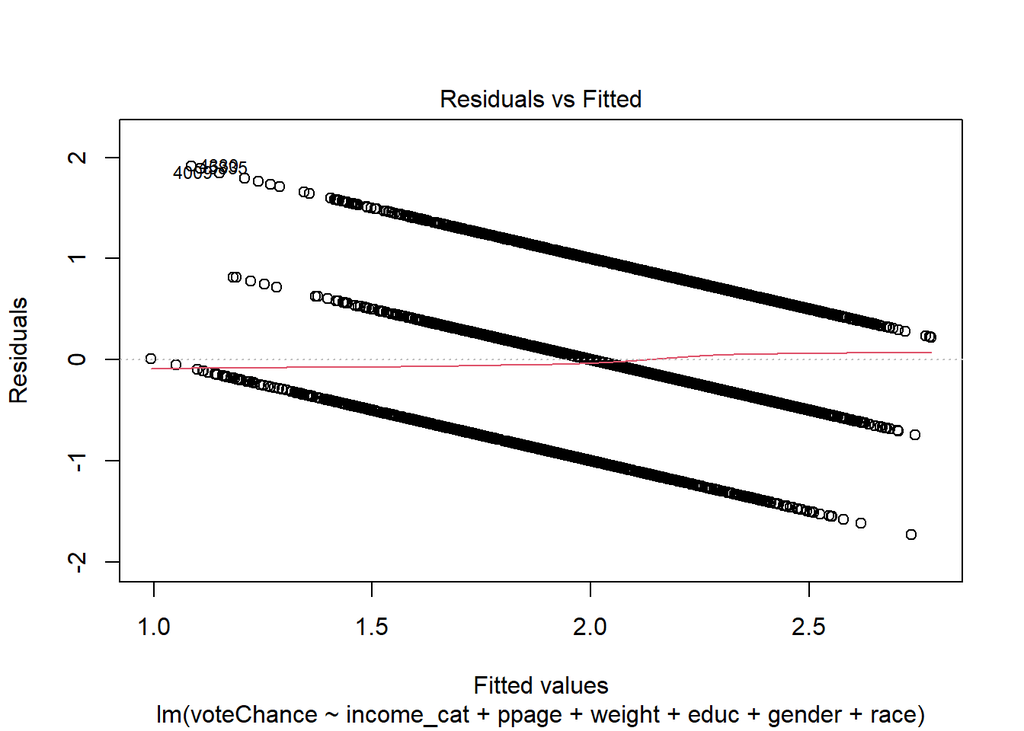

```r
plot(lmodb1, which = 1)
```

The residuals vs fitted plot shows three distinct lines (as voter category has only three possible values), though the trend line shows very little structure.

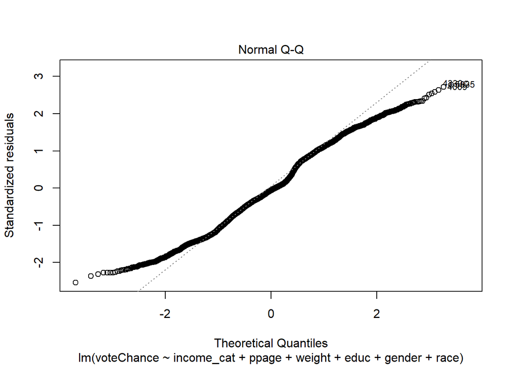

```r
plot(lmodb1, which = 2)
```

The normal Q-Q plot shows that the data is fairly normal towards the center, but deviates at the edges. A transformation (such as a square root or logarithm) would help to correct this, but is not needed as the MLR model was fitted purely just to see what would happen.

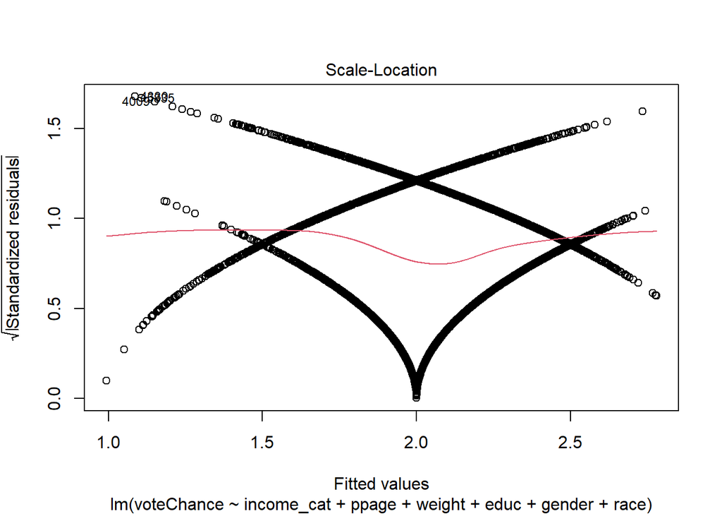

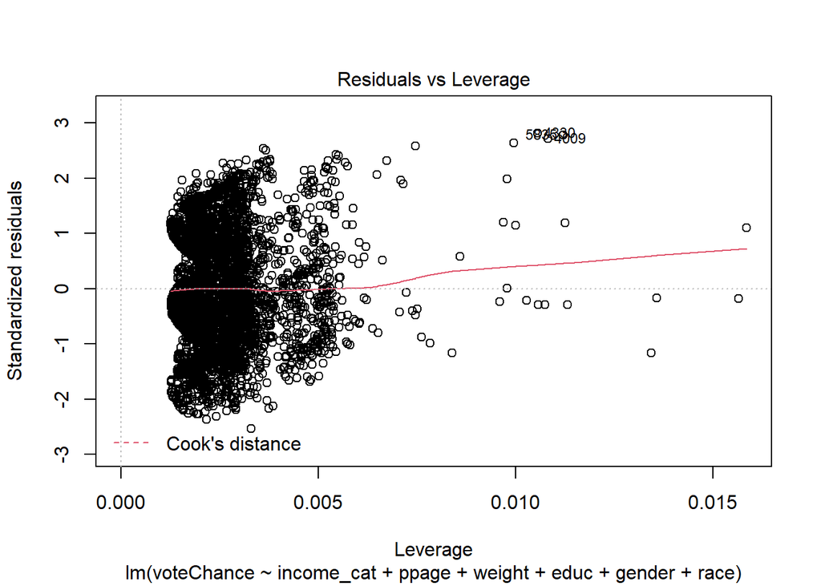

```r
plot(lmodb1, which = c(3, 5))
```

The scale-location and residuals vs leverage plots are also very funky. In short, and MLR model yields some entertaining results and plots, but is not particularly useful. It is tempting to transform the predicted values to each voter category (based on which is closest numerically) to see how accurate it would be. This would be rather time consuming, and be fairly useless.

Thankfully, there is a MUCH more effective and correct way to build a model on data like this. This method is known as Ordinal Logistic Regression (OLR), a type of logistic regression. Logistic regression is used for classification, when the response variable is categorical. Without going into too much detail, logistic regression models a likelihood function with coefficients for each predictor. For a given input probabilities are calculated for each response category, and the one with the highest likelihood is selected. There are many types of logistic regression to be used in many different scenarios, such as binary, multinomial, and ordinal. Ordinal logistic regression is used when there are more than two levels of the response variable, and a natural order exists between the levels. Examples of this include performance categories (Over performing, performing as expected, underperforming) and likelihood categories (Very likely, somewhat likely, not likely). OLR is perfect for this data set, as a natural order exists among the voter categories.

```r
basicOLR <- polr(voter_category ~ income_cat + educ + gender + ppage + weight + race, data = basicTraining, Hess = TRUE)
summary(basicOLR)
```

```
## Call:
## polr(formula = voter_category ~ income_cat + educ + gender +
##     ppage + weight + race, data = basicTraining, Hess = TRUE)
##
## Coefficients:
##                             Value Std. Error t value
## income_cat$40-75k        -0.25073   0.090858 -2.7596
## income_cat$75-125k       -0.05291   0.084407 -0.6269
## income_catLess than $40k -0.76358   0.098757 -7.7319
## educHigh school or less  -0.55882   0.099802 -5.5993
## educSome college         -0.08831   0.076817 -1.1496
## genderMale               -0.21398   0.059298 -3.6085
## ppage                     0.03731   0.002142 17.4128
## weight                   -0.58507   0.138727 -4.2175
## raceHispanic             -0.28888   0.102566 -2.8165
## raceOther/Mixed          -0.42812   0.137075 -3.1233
## raceWhite                 0.13924   0.090148  1.5446
##
## Intercepts:
##                       Value   Std. Error t value
## rarely/never|sporadic -0.4077  0.2177    -1.8731
## sporadic|always        1.7815  0.2197     8.1080
##
## Residual Deviance: 9141.832
## AIC: 9167.832
```

P-values are not natively included in this summary, and can be added in afterwards.

```r
coefs <- coef(summary(basicOLR))
pval <- pnorm(abs(coefs[,"t value"]), lower.tail = FALSE) * 2
coefs <- cbind(coefs, "p value" = pval)

coefs
```

```
##                                Value  Std. Error    t value      p value
## income_cat$40-75k        -0.25073039 0.090858337 -2.7595749 5.787661e-03
## income_cat$75-125k       -0.05291226 0.084406995 -0.6268705 5.307441e-01
## income_catLess than $40k -0.76357682 0.098756950 -7.7318794 1.059703e-14
## educHigh school or less  -0.55881730 0.099802059 -5.5992562 2.152735e-08
## educSome college         -0.08831055 0.076816876 -1.1496243 2.502987e-01
## genderMale               -0.21397547 0.059298102 -3.6084707 3.080073e-04
## ppage                     0.03730525 0.002142399 17.4128382 6.593270e-68
## weight                   -0.58507445 0.138726970 -4.2174528 2.470775e-05
## raceHispanic             -0.28887873 0.102566290 -2.8165076 4.854890e-03
## raceOther/Mixed          -0.42812121 0.137075187 -3.1232583 1.788607e-03
## raceWhite                 0.13924118 0.090147578  1.5445915 1.224451e-01
## rarely/never|sporadic    -0.40768204 0.217654438 -1.8730702 6.105869e-02
## sporadic|always           1.78148718 0.219720611  8.1079657 5.147426e-16
```

As can be seen, almost every predictor was significant, with highschool or less education, income of less than $40k, and age having significantly lower p values than the other variables, and having some of the largest influence on voter category.

#### Testing the Basic Model

Now that a prediction model has been built, it can be tested on the testing data. The result of this is a matrix known as the confusion matrix. This matrix breaks down the predicted vs actual voter categories. Anything on the main diagonal was placed into the correct category. This provides valueable insight to not only the overall accuracy of the model, but which individual categories the model is having trouble predicting.

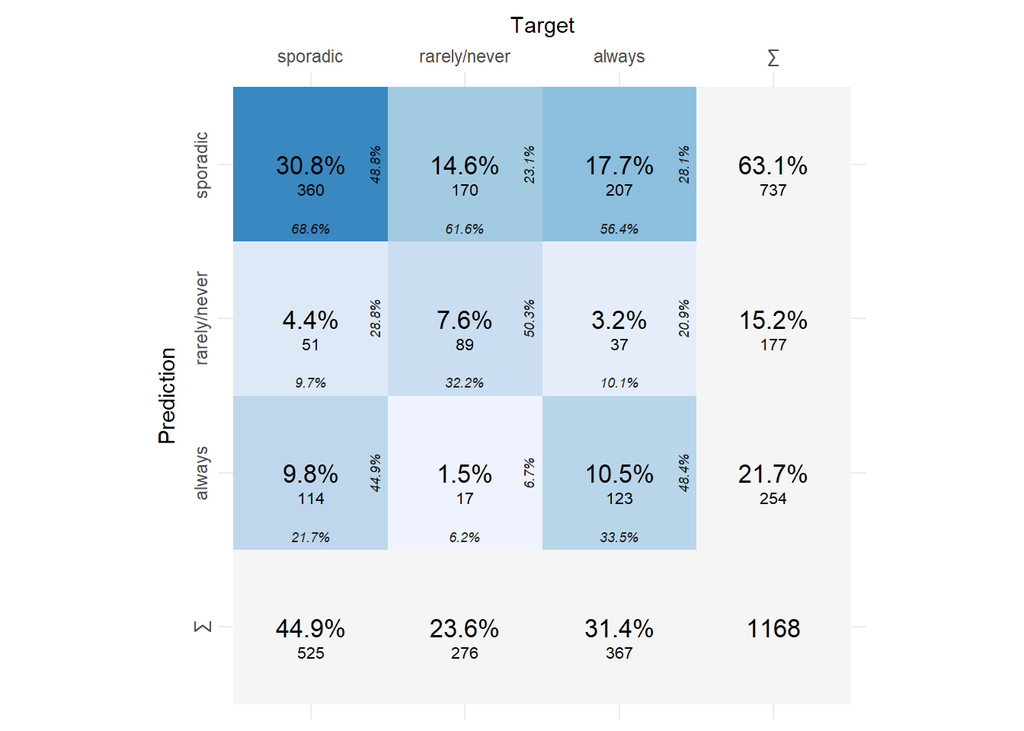

```r
predictBasic = predict(basicOLR, basicTesting)

predBasic_df <- tibble("target" = basicTesting$voter_category, "prediction" = predictBasic)

basic_conf_mat <- confusion_matrix(targets = predBasic_df$target, predictions = predBasic_df$prediction)
plot_confusion_matrix(basic_conf_mat$'Confusion Matrix'[[1]], add_sums = TRUE)
```

```r
confusionMatrix(predBasic_df$prediction, predBasic_df$target)
```

```
## Confusion Matrix and Statistics
##
##               Reference
## Prediction     rarely/never sporadic always
##   rarely/never           89       51     37
##   sporadic              170      360    207
##   always                 17      114    123
##
## Overall Statistics
##
##                Accuracy : 0.4897
##                  95% CI : (0.4607, 0.5188)
##     No Information Rate : 0.4495
##     P-Value [Acc > NIR] : 0.003166
##
##                   Kappa : 0.1665
##
##  Mcnemar's Test P-Value : < 2.2e-16
##
## Statistics by Class:
##
##                      Class: rarely/never Class: sporadic Class: always
## Sensitivity                       0.3225          0.6857        0.3351
## Specificity                       0.9013          0.4137        0.8365
## Pos Pred Value                    0.5028          0.4885        0.4843
## Neg Pred Value                    0.8113          0.6172        0.7330
## Prevalence                        0.2363          0.4495        0.3142
## Detection Rate                    0.0762          0.3082        0.1053
## Detection Prevalence              0.1515          0.6310        0.2175
## Balanced Accuracy                 0.6119          0.5497        0.5858
```

```r
vif(basicOLR)
```

```
##                GVIF Df GVIF^(1/(2*Df))
## income_cat 1.567777  3        1.077823
## educ       2.199421  2        1.217803
## gender     1.117567  1        1.057151
## ppage      1.447035  1        1.202928
## weight     2.584737  1        1.607712
## race       1.510401  3        1.071146
```

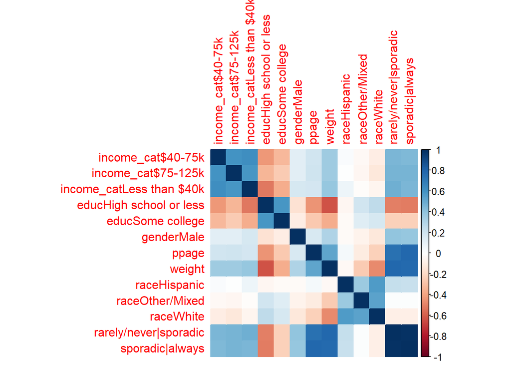

```r
corrplot(cov2cor(vcov(basicOLR)), method = "color")
```

The VIFs look fairly good, though weight and education both have higher factors than the rest. The correlation plot also demonstrates this. We can remove weight from the model to correct this, and find out if it has any effect on the overall fit.

```r
basicOLR_r <- polr(voter_category ~ educ + income_cat + race + gender + ppage , data = basicTraining, Hess = TRUE)
summary(basicOLR_r)
```

```
## Call:
## polr(formula = voter_category ~ educ + income_cat + race + gender +
##     ppage, data = basicTraining, Hess = TRUE)
##
## Coefficients:
##                             Value Std. Error  t value
## educHigh school or less  -0.83142   0.076701 -10.8397
## educSome college         -0.20594   0.071659  -2.8739
## income_cat$40-75k        -0.11586   0.085006  -1.3630
## income_cat$75-125k        0.07293   0.079032   0.9227
## income_catLess than $40k -0.60405   0.091022  -6.6363
## raceHispanic             -0.30279   0.101833  -2.9734
## raceOther/Mixed          -0.57589   0.131990  -4.3631
## raceWhite                -0.03738   0.079133  -0.4724
## genderMale               -0.13913   0.056490  -2.4629
## ppage                     0.04216   0.001828  23.0561
##
## Intercepts:
##                       Value    Std. Error t value
## rarely/never|sporadic   0.3243   0.1331     2.4371
## sporadic|always         2.5082   0.1387    18.0819
##
## Residual Deviance: 9160.058
## AIC: 9184.058
```

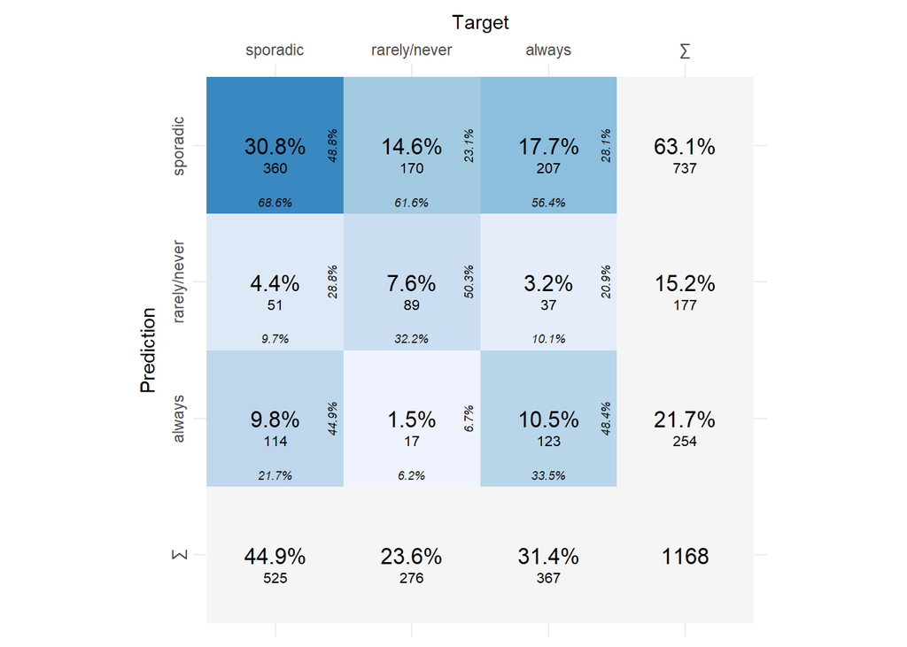

```r
predictBasic = predict(basicOLR, basicTesting)

predBasic_df <- tibble("target" = basicTesting$voter_category, "prediction" = predictBasic)

basic_conf_mat <- confusion_matrix(targets = predBasic_df$target, predictions = predBasic_df$prediction)
plot_confusion_matrix(basic_conf_mat$'Confusion Matrix'[[1]], add_sums = TRUE)
```

```r
confusionMatrix(predBasic_df$prediction, predBasic_df$target)
```

```
## Confusion Matrix and Statistics
##
##               Reference
## Prediction     rarely/never sporadic always
##   rarely/never           89       51     37
##   sporadic              170      360    207
##   always                 17      114    123
##
## Overall Statistics
##
##                Accuracy : 0.4897
##                  95% CI : (0.4607, 0.5188)
##     No Information Rate : 0.4495
##     P-Value [Acc > NIR] : 0.003166
##
##                   Kappa : 0.1665
##
##  Mcnemar's Test P-Value : < 2.2e-16
##
## Statistics by Class:
##
##                      Class: rarely/never Class: sporadic Class: always
## Sensitivity                       0.3225          0.6857        0.3351
## Specificity                       0.9013          0.4137        0.8365
## Pos Pred Value                    0.5028          0.4885        0.4843
## Neg Pred Value                    0.8113          0.6172        0.7330
## Prevalence                        0.2363          0.4495        0.3142
## Detection Rate                    0.0762          0.3082        0.1053
## Detection Prevalence              0.1515          0.6310        0.2175
## Balanced Accuracy                 0.6119          0.5497        0.5858
```

```r
anova(basicOLR, basicOLR_r)
```

```
## Likelihood ratio tests of ordinal regression models
##
## Response: voter_category
##                                                Model Resid. df Resid. Dev
## 1          educ + income_cat + race + gender + ppage      4656   9160.058
## 2 income_cat + educ + gender + ppage + weight + race      4655   9141.832
##     Test    Df LR stat.      Pr(Chi)
## 1
## 2 1 vs 2     1 18.22566 1.962173e-05
```

While the reduced model is slightly more simple, the full model is still better. The P-value is extremely low, though the likelihood radio statistic is fairly small, indicating that the difference isn’t very large even if it is statistically significant.

## Part 2: The Full Dataset

Part 2 of this analysis will use the methods of part 1, but applied to a larger set of variables. Hopefully this will lead to insight as to a voter’s attitude towards the election and/or government, experiencing barriers to voting, party affiliation, and how this influences their likelihood to vote. Many of the variables in the full set include several parts, such as trust in the many parts of government, or experiencing barriers of entry to voting. There are 79 total independent variables, in contrast to part 1’s 6. For sake of simplicity only a few variables have been plotted and have ANOVA results.

### 2a: Analysis

[figure not shown]

```r
trust1 <- ggplot(vote, aes(x = factor(Q8_1, levels = c("A lot", "Some", "Not much", "Not at all", "No Response")), fill = factor(voter_category, levels = c("rarely/never", "sporadic", "always")))) + # Create basic Plot
  geom_bar(position = "fill") +
  xlab("Trust Level") + ylab("% of Respondents") + ggtitle("Trust in The Presidency") +# Add axis labels
  guides(fill = guide_legend(title = "Voter Category")) +
  theme(axis.text.x = element_text(angle = 90, vjust = 0.5, hjust=1)) # Rotate category labels

trust2 <- ggplot(vote, aes(x = factor(Q8_2, levels = c("A lot", "Some", "Not much", "Not at all", "No Response")), fill = factor(voter_category, levels = c("rarely/never", "sporadic", "always")))) + # Create basic Plot
  geom_bar(position = "fill") +
  xlab("Trust Level") + ylab("% of Respondents") + ggtitle("Trust in Congress") +# Add axis labels
  guides(fill = guide_legend(title = "Voter Category")) +
  theme(axis.text.x = element_text(angle = 90, vjust = 0.5, hjust=1)) # Rotate category labels

trust3 <- ggplot(vote, aes(x = factor(Q8_1, levels = c("A lot", "Some", "Not much", "Not at all", "No Response")), fill = factor(voter_category, levels = c("rarely/never", "sporadic", "always")))) + # Create basic Plot
  geom_bar(position = "fill") +
  xlab("Trust Level") + ylab("% of Respondents") + ggtitle("Trust in The Supreme Court") +# Add axis labels
  guides(fill = guide_legend(title = "Voter Category")) +
  theme(axis.text.x = element_text(angle = 90, vjust = 0.5, hjust=1)) # Rotate category labels

trust4 <- ggplot(vote, aes(x = factor(Q8_4, levels = c("A lot", "Some", "Not much", "Not at all", "No Response")), fill = factor(voter_category, levels = c("rarely/never", "sporadic", "always")))) + # Create basic Plot
  geom_bar(position = "fill") +
  xlab("Trust Level") + ylab("% of Respondents") + ggtitle("Trust in The CDC") +# Add axis labels
  guides(fill = guide_legend(title = "Voter Category")) +
  theme(axis.text.x = element_text(angle = 90, vjust = 0.5, hjust=1)) # Rotate category labels

trust5 <- ggplot(vote, aes(x = factor(Q8_5, levels = c("A lot", "Some", "Not much", "Not at all", "No Response")), fill = factor(voter_category, levels = c("rarely/never", "sporadic", "always")))) + # Create basic Plot
  geom_bar(position = "fill") +
  xlab("Trust Level") + ylab("% of Respondents") + ggtitle("Trust in Election Officials") +# Add axis labels
  guides(fill = guide_legend(title = "Voter Category")) +
  theme(axis.text.x = element_text(angle = 90, vjust = 0.5, hjust=1)) # Rotate category labels

trust6 <- ggplot(vote, aes(x = factor(Q8_6, levels = c("A lot", "Some", "Not much", "Not at all", "No Response")), fill = factor(voter_category, levels = c("rarely/never", "sporadic", "always")))) + # Create basic Plot
  geom_bar(position = "fill") +
  xlab("Trust Level") + ylab("% of Respondents") + ggtitle("Trust in The Intelligence Community") +# Add axis labels
  guides(fill = guide_legend(title = "Voter Category")) +
  theme(axis.text.x = element_text(angle = 90, vjust = 0.5, hjust=1)) # Rotate category labels

trust7 <- ggplot(vote, aes(x = factor(Q8_7, levels = c("A lot", "Some", "Not much", "Not at all", "No Response")), fill = factor(voter_category, levels = c("rarely/never", "sporadic", "always")))) + # Create basic Plot
  geom_bar(position = "fill") +
  xlab("Trust Level") + ylab("% of Respondents") + ggtitle("Trust in News Media") +# Add axis labels
  guides(fill = guide_legend(title = "Voter Category")) +
  theme(axis.text.x = element_text(angle = 90, vjust = 0.5, hjust=1)) # Rotate category labels

trust8 <- ggplot(vote, aes(x = factor(Q8_8, levels = c("A lot", "Some", "Not much", "Not at all", "No Response")), fill = factor(voter_category, levels = c("rarely/never", "sporadic", "always")))) + # Create basic Plot
  geom_bar(position = "fill") +
  xlab("Trust Level") + ylab("% of Respondents") + ggtitle("Trust in The Police") +# Add axis labels
  guides(fill = guide_legend(title = "Voter Category")) +
  theme(axis.text.x = element_text(angle = 90, vjust = 0.5, hjust=1)) # Rotate category labels

trust9 <- ggplot(vote, aes(x = factor(Q8_9, levels = c("A lot", "Some", "Not much", "Not at all", "No Response")), fill = factor(voter_category, levels = c("rarely/never", "sporadic", "always")))) + # Create basic Plot
  geom_bar(position = "fill") +
  xlab("Trust Level") + ylab("% of Respondents") + ggtitle("Trust in The Post Office") +# Add axis labels
  guides(fill = guide_legend(title = "Voter Category")) +
  theme(axis.text.x = element_text(angle = 90, vjust = 0.5, hjust=1)) # Rotate category labels

plot_grid(trust1, trust2, trust3, trust4, trust5, trust6, trust7, trust8, trust9)
```

The plots above show each variable that asked respondents about their trust in government. As expected, generally the less someone trusts the government, the more likely they are to be part of the rarely/never voting category. Interestingly those who refused to answer the question were much more likely to be part of that category.

Next, AOV tests can be conducted to determine which variables are significant in a difference of mean voter category. For simplicity and time constraints, the difference between specific levels will not be examined at this time.

```r
summary(aov(voteChance ~ Q8_1, data = vote))
```

```
##               Df Sum Sq Mean Sq F value   Pr(>F)
## Q8_1           4     32   8.037   14.61 7.06e-12 ***
## Residuals   5831   3208   0.550
## ---
## Signif. codes:  0 '***' 0.001 '**' 0.01 '*' 0.05 '.' 0.1 ' ' 1
```

```r
summary(aov(vote$voteChance ~ vote$Q8_2))
```

```
##               Df Sum Sq Mean Sq F value  Pr(>F)
## vote$Q8_2      4      9   2.370   4.279 0.00185 **
## Residuals   5831   3230   0.554
## ---
## Signif. codes:  0 '***' 0.001 '**' 0.01 '*' 0.05 '.' 0.1 ' ' 1
```

```r
summary(aov(vote$voteChance ~ vote$Q8_3))
```

```
##               Df Sum Sq Mean Sq F value Pr(>F)
## vote$Q8_3      4     55  13.867   25.39 <2e-16 ***
## Residuals   5831   3184   0.546
## ---
## Signif. codes:  0 '***' 0.001 '**' 0.01 '*' 0.05 '.' 0.1 ' ' 1
```

```r
summary(aov(vote$voteChance ~ vote$Q8_4))
```

```
##               Df Sum Sq Mean Sq F value   Pr(>F)
## vote$Q8_4      4     20   5.080     9.2 2.09e-07 ***
## Residuals   5831   3219   0.552
## ---
## Signif. codes:  0 '***' 0.001 '**' 0.01 '*' 0.05 '.' 0.1 ' ' 1
```

```r
summary(aov(vote$voteChance ~ vote$Q8_5))
```

```
##               Df Sum Sq Mean Sq F value Pr(>F)
## vote$Q8_5      4   89.2   22.31   41.28 <2e-16 ***
## Residuals   5831 3150.6    0.54
## ---
## Signif. codes:  0 '***' 0.001 '**' 0.01 '*' 0.05 '.' 0.1 ' ' 1
```

```r
summary(aov(vote$voteChance ~ vote$Q8_6))
```

```
##               Df Sum Sq Mean Sq F value   Pr(>F)
## vote$Q8_6      4     42  10.616   19.36 7.74e-16 ***
## Residuals   5831   3197   0.548
## ---
## Signif. codes:  0 '***' 0.001 '**' 0.01 '*' 0.05 '.' 0.1 ' ' 1
```

```r
summary(aov(vote$voteChance ~ vote$Q8_7))
```

```
##               Df Sum Sq Mean Sq F value Pr(>F)
## vote$Q8_7      4     45  11.337   20.69 <2e-16 ***
## Residuals   5831   3194   0.548
## ---
## Signif. codes:  0 '***' 0.001 '**' 0.01 '*' 0.05 '.' 0.1 ' ' 1
```

```r
summary(aov(vote$voteChance ~ vote$Q8_8))
```

```
##               Df Sum Sq Mean Sq F value Pr(>F)
## vote$Q8_8      4     71  17.837   32.83 <2e-16 ***
## Residuals   5831   3168   0.543
## ---
## Signif. codes:  0 '***' 0.001 '**' 0.01 '*' 0.05 '.' 0.1 ' ' 1
```

```r
summary(aov(vote$voteChance ~ vote$Q8_9))
```

```
##               Df Sum Sq Mean Sq F value   Pr(>F)
## vote$Q8_9      4     28   6.886    12.5 3.99e-10 ***
## Residuals   5831   3212   0.551
## ---
## Signif. codes:  0 '***' 0.001 '**' 0.01 '*' 0.05 '.' 0.1 ' ' 1
```

These same steps will be repeated for barriers of entry to voting.

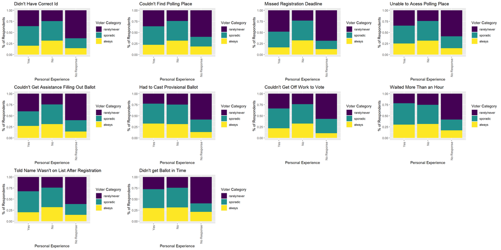

```r
barrier1 <- ggplot(vote, aes(x = factor(Q18_1, levels = c("Yes", "No", "Not at all", "No Response")), fill = factor(voter_category, levels = c("rarely/never", "sporadic", "always")))) + # Create basic Plot
  geom_bar(position = "fill") +
  xlab("Personal Experience") + ylab("% of Respondents") + ggtitle("Didn't Have Correct Id") +# Add axis labels
  guides(fill = guide_legend(title = "Voter Category")) +
  theme(axis.text.x = element_text(angle = 90, vjust = 0.5, hjust=1)) # Rotate category labels

barrier2 <- ggplot(vote, aes(x = factor(Q18_2, levels = c("Yes", "No", "Not at all", "No Response")), fill = factor(voter_category, levels = c("rarely/never", "sporadic", "always")))) + # Create basic Plot
  geom_bar(position = "fill") +
  xlab("Personal Experience") + ylab("% of Respondents") + ggtitle("Couldn't Find Polling Place") +# Add axis labels
  guides(fill = guide_legend(title = "Voter Category")) +
  theme(axis.text.x = element_text(angle = 90, vjust = 0.5, hjust=1)) # Rotate category labels

barrier3 <- ggplot(vote, aes(x = factor(Q18_3, levels = c("Yes", "No", "Not at all", "No Response")), fill = factor(voter_category, levels = c("rarely/never", "sporadic", "always")))) + # Create basic Plot
  geom_bar(position = "fill") +
  xlab("Personal Experience") + ylab("% of Respondents") + ggtitle("Missed Registration Deadline") +# Add axis labels
  guides(fill = guide_legend(title = "Voter Category")) +
  theme(axis.text.x = element_text(angle = 90, vjust = 0.5, hjust=1)) # Rotate category labels

barrier4 <- ggplot(vote, aes(x = factor(Q18_4, levels = c("Yes", "No", "Not at all", "No Response")), fill = factor(voter_category, levels = c("rarely/never", "sporadic", "always")))) + # Create basic Plot
  geom_bar(position = "fill") +
  xlab("Personal Experience") + ylab("% of Respondents") + ggtitle("Unable to Acess Polling Place") +# Add axis labels
  guides(fill = guide_legend(title = "Voter Category")) +
  theme(axis.text.x = element_text(angle = 90, vjust = 0.5, hjust=1)) # Rotate category labels

barrier5 <- ggplot(vote, aes(x = factor(Q18_5, levels = c("Yes", "No", "Not at all", "No Response")), fill = factor(voter_category, levels = c("rarely/never", "sporadic", "always")))) + # Create basic Plot
  geom_bar(position = "fill") +
  xlab("Personal Experience") + ylab("% of Respondents") + ggtitle("Couldn't Get Assistance Filling Out Ballot") +# Add axis labels
  guides(fill = guide_legend(title = "Voter Category")) +
  theme(axis.text.x = element_text(angle = 90, vjust = 0.5, hjust=1)) # Rotate category labels

barrier6 <- ggplot(vote, aes(x = factor(Q18_6, levels = c("Yes", "No", "Not at all", "No Response")), fill = factor(voter_category, levels = c("rarely/never", "sporadic", "always")))) + # Create basic Plot
  geom_bar(position = "fill") +
  xlab("Personal Experience") + ylab("% of Respondents") + ggtitle("Had to Cast Provisional Ballot") +# Add axis labels
  guides(fill = guide_legend(title = "Voter Category")) +
  theme(axis.text.x = element_text(angle = 90, vjust = 0.5, hjust=1)) # Rotate category labels

barrier7 <- ggplot(vote, aes(x = factor(Q18_7, levels = c("Yes", "No", "Not at all", "No Response")), fill = factor(voter_category, levels = c("rarely/never", "sporadic", "always")))) + # Create basic Plot
  geom_bar(position = "fill") +
  xlab("Personal Experience") + ylab("% of Respondents") + ggtitle("Couldn't Get Off Work to Vote") +# Add axis labels
  guides(fill = guide_legend(title = "Voter Category")) +
  theme(axis.text.x = element_text(angle = 90, vjust = 0.5, hjust=1)) # Rotate category labels

barrier8 <- ggplot(vote, aes(x = factor(Q18_8, levels = c("Yes", "No", "Not at all", "No Response")), fill = factor(voter_category, levels = c("rarely/never", "sporadic", "always")))) + # Create basic Plot
  geom_bar(position = "fill") +
  xlab("Personal Experience") + ylab("% of Respondents") + ggtitle("Waited More Than an Hour") +# Add axis labels
  guides(fill = guide_legend(title = "Voter Category")) +
  theme(axis.text.x = element_text(angle = 90, vjust = 0.5, hjust=1)) # Rotate category labels

barrier9 <- ggplot(vote, aes(x = factor(Q18_9, levels = c("Yes", "No", "Not at all", "No Response")), fill = factor(voter_category, levels = c("rarely/never", "sporadic", "always")))) + # Create basic Plot
  geom_bar(position = "fill") +
  xlab("Personal Experience") + ylab("% of Respondents") + ggtitle("Told Name Wasn't on List After Registration") +# Add axis labels
  guides(fill = guide_legend(title = "Voter Category")) +
  theme(axis.text.x = element_text(angle = 90, vjust = 0.5, hjust=1)) # Rotate category labels

barrier10 <- ggplot(vote, aes(x = factor(Q18_10, levels = c("Yes", "No", "Not at all", "No Response")), fill = factor(voter_category, levels = c("rarely/never", "sporadic", "always")))) + # Create basic Plot
  geom_bar(position = "fill") +
  xlab("Personal Experience") + ylab("% of Respondents") + ggtitle("Didn't get Ballot in Time") +# Add axis labels
  guides(fill = guide_legend(title = "Voter Category")) +
  theme(axis.text.x = element_text(angle = 90, vjust = 0.5, hjust=1)) # Rotate category labels
plot_grid(barrier1, barrier2, barrier3, barrier4, barrier5, barrier6, barrier7, barrier8, barrier9, barrier10)
```

The barriers of entry experienced include waiting more than an hour, being unable to find a polling place, and not receiving a ballot in time. Again, as expected if a respondent experienced a barrier of entry, they appear to be less likely to vote. Similarly to the trust in government plots, participants who refused to answer the question were much more likely to be a non-voter. This group for any of these given variables consists of ~50 or so total responses. While making up only ~1% of the survey responses, it is still a strong indicator that someone would be part of the nonvoter category. This will be quantified with AOV tests, in addition to a TukeyHSD test to examine the significance of the “No Response” category.

```r
TukeyHSD(aov(vote$voteChance ~ vote$Q18_1))
```

```
##   Tukey multiple comparisons of means
##     95% family-wise confidence level
##
## Fit: aov(formula = vote$voteChance ~ vote$Q18_1)
##
## $`vote$Q18_1`
##                       diff         lwr         upr     p adj
## No-Yes           0.2305035  0.09301031  0.36799677 0.0002532
## No Response-Yes -0.3322202 -0.61543034 -0.04900999 0.0164668
## No Response-No  -0.5627237 -0.81248684 -0.31296056 0.0000004
```

```r
summary(aov(vote$voteChance ~ vote$Q18_2))
```

```
##               Df Sum Sq Mean Sq F value   Pr(>F)
## vote$Q18_2     2     26  12.784    23.2 9.21e-11 ***
## Residuals   5833   3214   0.551
## ---
## Signif. codes:  0 '***' 0.001 '**' 0.01 '*' 0.05 '.' 0.1 ' ' 1
```

```r
summary(aov(vote$voteChance ~ vote$Q18_3))
```

```
##               Df Sum Sq Mean Sq F value Pr(>F)
## vote$Q18_3     2     71   35.51   65.37 <2e-16 ***
## Residuals   5833   3169    0.54
## ---
## Signif. codes:  0 '***' 0.001 '**' 0.01 '*' 0.05 '.' 0.1 ' ' 1
```

```r
summary(aov(vote$voteChance ~ vote$Q18_4))
```

```
##               Df Sum Sq Mean Sq F value   Pr(>F)
## vote$Q18_4     2     21  10.617   19.24 4.69e-09 ***
## Residuals   5833   3219   0.552
## ---
## Signif. codes:  0 '***' 0.001 '**' 0.01 '*' 0.05 '.' 0.1 ' ' 1
```

```r
summary(aov(vote$voteChance ~ vote$Q18_5))
```

```
##               Df Sum Sq Mean Sq F value   Pr(>F)
## vote$Q18_5     2     18   9.056   16.39 7.93e-08 ***
## Residuals   5833   3222   0.552
## ---
## Signif. codes:  0 '***' 0.001 '**' 0.01 '*' 0.05 '.' 0.1 ' ' 1
```

```r
summary(aov(vote$voteChance ~ vote$Q18_6))
```

```
##               Df Sum Sq Mean Sq F value   Pr(>F)
## vote$Q18_6     2     14   7.179   12.98 2.37e-06 ***
## Residuals   5833   3225   0.553
## ---
## Signif. codes:  0 '***' 0.001 '**' 0.01 '*' 0.05 '.' 0.1 ' ' 1
```

```r
summary(aov(vote$voteChance ~ vote$Q18_7))
```

```
##               Df Sum Sq Mean Sq F value   Pr(>F)
## vote$Q18_7     2     36  18.193   33.13 4.94e-15 ***
## Residuals   5833   3203   0.549
## ---
## Signif. codes:  0 '***' 0.001 '**' 0.01 '*' 0.05 '.' 0.1 ' ' 1
```

```r
summary(aov(vote$voteChance ~ vote$Q18_8))
```

```
##               Df Sum Sq Mean Sq F value  Pr(>F)
## vote$Q18_8     2     13   6.281   11.35 1.2e-05 ***
## Residuals   5833   3227   0.553
## ---
## Signif. codes:  0 '***' 0.001 '**' 0.01 '*' 0.05 '.' 0.1 ' ' 1
```

```r
summary(aov(vote$voteChance ~ vote$Q18_9))
```

```
##               Df Sum Sq Mean Sq F value   Pr(>F)
## vote$Q18_9     2     24  11.817   21.43 5.33e-10 ***
## Residuals   5833   3216   0.551
## ---
## Signif. codes:  0 '***' 0.001 '**' 0.01 '*' 0.05 '.' 0.1 ' ' 1
```

```r
summary(aov(vote$voteChance ~ vote$Q18_10))
```

```
##               Df Sum Sq Mean Sq F value   Pr(>F)
## vote$Q18_10    2     11   5.559   10.04 4.42e-05 ***
## Residuals   5833   3229   0.554
## ---
## Signif. codes:  0 '***' 0.001 '**' 0.01 '*' 0.05 '.' 0.1 ' ' 1
```

Every single barrier of entry variable was associated with a difference in mean voter category. The tukeyHSD test also demonstrates that the “no response” category is statistically significant in this context, and is associated with a much larger difference than the other two levels.

So far this has only examined 25 out of the total of 79 variables. For sake of time visualizations and AOV tests will not be shown for the remainder of the prediction variables. It can be concluded that lack of trust in the various aspects of government and experiencing barriers of entry to voting do have a significant impact on a participants likelihood to vote. In addition, a lack of cooperation in the survey is also associated with this, with a much larger effect.

### 2b: Prediction Model

#### The Full Model

A prediction model based off of the entire set of predictors (aside from those left out in the initial setup) can now be fitted. As it has already been demonstrated in this project, and MLR model is not particularly useful. As such an ordinal logistic regression model will be fitted, and compared to the initial basic model. As there are literally hundreds of coefficients, the summary of the model has been left out in favor of the prediction results. To examine the meaning of each variable, the code book is linked here: https://github.com/fivethirtyeight/data/blob/master/non-voters/nonvoters_codebook.pdf

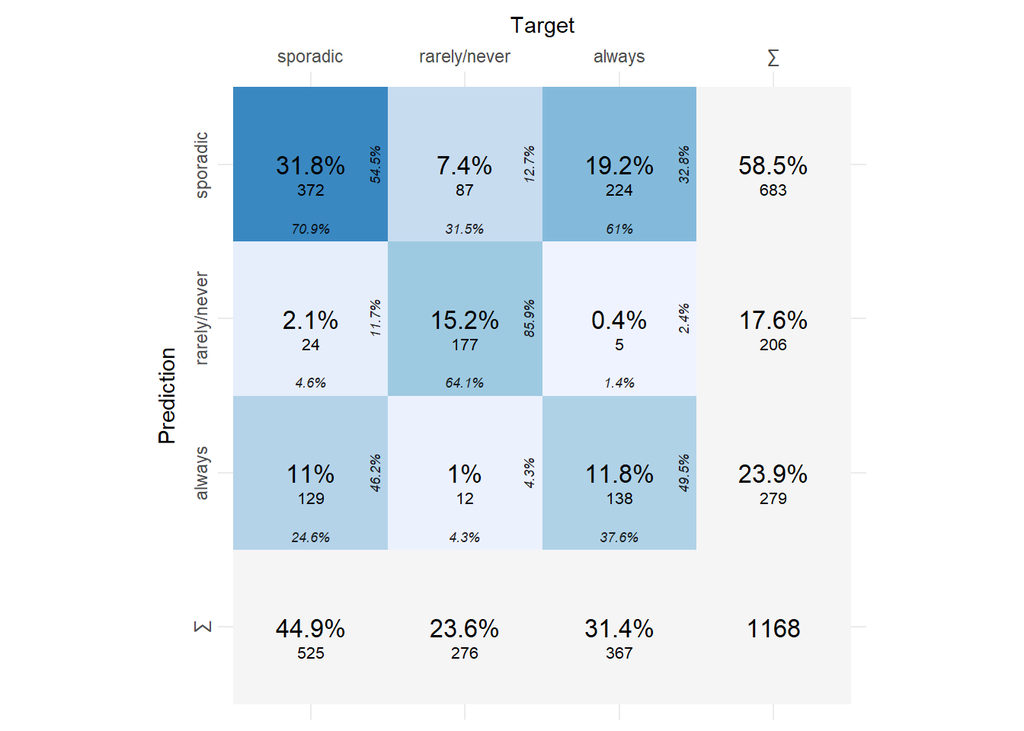

```r
# Full OLR Model

fullOLR <- polr(voter_category ~ educ + income_cat + race + gender + ppage + weight + Q2_1 + Q2_2 + Q2_3 + Q2_3 + Q2_4 + Q2_5 + Q2_6 + Q2_7 + Q2_8 + Q2_9 + Q2_10 + Q3_1 + Q3_2 + Q3_3 + Q3_4 + Q3_5 + Q3_6 + Q4_1 + Q4_2 + Q4_3 + Q4_4 + Q4_5 + Q4_6 + Q5 + Q6 + Q7 + Q8_1 + Q8_2 + Q8_3 + Q8_4 + Q8_5 + Q8_6 + Q8_7 + Q8_8 + Q8_9 + Q9_1 + Q9_2 + Q9_3 + Q9_4 + Q10_1 + Q10_2 + Q10_3 + Q10_4 + Q11_1 + Q11_2 + Q11_3 + Q11_4 + Q11_5 + Q11_6 + Q14 + Q15 + Q16 + Q17_1 + Q17_2 + Q17_3 + Q17_4 + Q18_1 + Q18_2 + Q18_3 + Q18_4 + Q18_5 + Q18_6 + Q18_7 + Q18_8 + Q18_9 + Q18_10 + Q20 + Q21 + Q23 + Q24 + Q25 + Q26 + Q30, data = voteTraining, Hess = TRUE)

predictVote = predict(fullOLR, voteTesting)

predFull_df <- tibble("target" = voteTesting$voter_category, "prediction" = predictVote)

full_conf_mat <- confusion_matrix(targets = predFull_df$target, predictions = predFull_df$prediction)
plot_confusion_matrix(full_conf_mat$'Confusion Matrix'[[1]], add_sums = TRUE)
```

```r
confusionMatrix(predFull_df$prediction, predFull_df$target)
```

```
## Confusion Matrix and Statistics
##
##               Reference
## Prediction     rarely/never sporadic always
##   rarely/never          177       24      5
##   sporadic               87      372    224
##   always                 12      129    138
##
## Overall Statistics
##
##                Accuracy : 0.5882
##                  95% CI : (0.5593, 0.6166)
##     No Information Rate : 0.4495
##     P-Value [Acc > NIR] : < 2.2e-16
##
##                   Kappa : 0.3362
##
##  Mcnemar's Test P-Value : 7.417e-14
##
## Statistics by Class:
##
##                      Class: rarely/never Class: sporadic Class: always
## Sensitivity                       0.6413          0.7086        0.3760
## Specificity                       0.9675          0.5163        0.8240
## Pos Pred Value                    0.8592          0.5447        0.4946
## Neg Pred Value                    0.8971          0.6845        0.7424
## Prevalence                        0.2363          0.4495        0.3142
## Detection Rate                    0.1515          0.3185        0.1182
## Detection Prevalence              0.1764          0.5848        0.2389
## Balanced Accuracy                 0.8044          0.6125        0.6000
```

Multicollinearity is likely a problem in this model, partially due to the nature of the questions. For some variables, respondents were given the same question repeatedly for different things, particularly shown in the trust in government plots. For example, if an individual does not have any trust in the presidency, it is not likely that they would have complete trust in congress or the supreme court. VIF’s can be used to confirm this

```r
vif(fullOLR)
```

```
##                 GVIF Df GVIF^(1/(2*Df))
## educ        2.777279  2        1.290937
## income_cat  2.249278  3        1.144653
## race        2.970974  3        1.198993
## gender      1.418341  1        1.190941
## ppage       2.272972  1        1.507638
## weight      2.970226  1        1.723434
## Q2_1        4.380287  4        1.202785
## Q2_2        2.653981  4        1.129763
## Q2_3        3.303387  4        1.161101
## Q2_4        6.101901  4        1.253670
## Q2_5        2.838988  4        1.139319
## Q2_6        5.264819  4        1.230759
## Q2_7        4.135938  4        1.194185
## Q2_8        2.080965  4        1.095931
## Q2_9        3.631626  4        1.174932
## Q2_10       3.013286  4        1.147837
## Q3_1       12.111280  4        1.365837
## Q3_2       10.802046  4        1.346444
## Q3_3        5.002184  4        1.222911
## Q3_4        7.427937  4        1.284868
## Q3_5        4.166366  4        1.195280
## Q3_6        5.365424  4        1.233674
## Q4_1       12.365781  4        1.369392
## Q4_2       20.649643  4        1.460038
## Q4_3       12.941739  4        1.377207
## Q4_4        5.181207  4        1.228298
## Q4_5        5.799798  4        1.245738
## Q4_6        8.109879  4        1.299053
## Q5          2.216066  2        1.220101
## Q6          2.616130  4        1.127736
## Q7          2.001992  2        1.189503
## Q8_1       10.468112  4        1.341169
## Q8_2        5.263480  4        1.230720
## Q8_3        4.892842  4        1.219537
## Q8_4        6.156225  4        1.255059
## Q8_5        5.124497  4        1.226610
## Q8_6       11.449529  4        1.356277
## Q8_7        8.223562  4        1.301315
## Q8_8        9.751123  4        1.329327
```

[output cut: 24 more lines]

```
## Q18_3       4.678140  2        1.470680
## Q18_4       4.920576  2        1.489375
## Q18_5       3.649564  2        1.382166
## Q18_6       4.587987  2        1.463543
## Q18_7       3.332543  2        1.351120
## Q18_8       3.672709  2        1.384352
## Q18_9      11.032952  2        1.822523
## Q18_10      4.045756  2        1.418241
## Q20         2.424487  2        1.247829
## Q21         2.778801  3        1.185704
## Q23        13.496416  3        1.543014
## Q24         4.604714  4        1.210320
## Q25         5.289939  4        1.231491
## Q26         5.376941  4        1.234005
## Q30        10.165178  5        1.260990
```

Many of these variables have high VIF’s with coefficients of many variables exceeding 5, several exceeding 10, and a few even exceeding 15. This is strong evidence that multicollinearity exists within the full model.

#### The Reduced Model

A reduced model will be constructed by removing the variable with the highest VIF until all are less than 10, using a backwards elimination method.

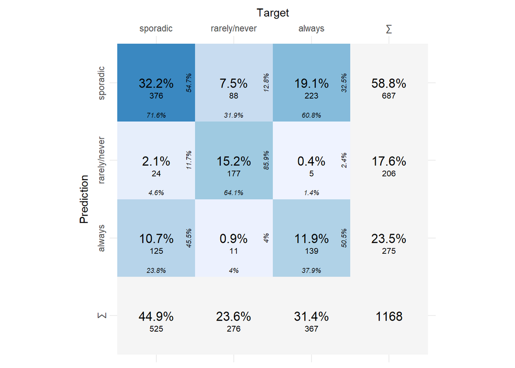

```r
reducedOLR <- polr(voter_category ~ educ + income_cat + race + gender + ppage + weight + Q2_1 + Q2_2 + Q2_3 + Q2_3 + Q2_4 + Q2_5 + Q2_6 + Q2_7 + Q2_8 + Q2_9 + Q2_10 + Q3_2 + Q3_3 + Q3_4 + Q3_5 + Q3_6 + Q4_1 + Q4_3 + Q4_4 + Q4_5 + Q4_6 + Q5 + Q6 + Q7 + Q8_1 + Q8_2 + Q8_3 + Q8_4 + Q8_5 + Q8_7 + Q8_8 + Q8_9 + Q9_1 + Q9_2 + Q9_3 + Q9_4 + Q10_1 + Q10_2 + Q10_3 + Q10_4 + Q11_1 + Q11_2 + Q11_3 + Q11_4 + Q11_5 + Q11_6 + Q14 + Q15 + Q16 + Q17_1 + Q17_2 + Q17_4 + Q18_1 + Q18_2 + Q18_3 + Q18_4 + Q18_5 + Q18_6 + Q18_7 + Q18_8 + Q18_10 + Q20 + Q21 + Q24 + Q25 + Q26 + Q30, data = voteTraining, Hess = TRUE)

#Removed: Q4_2, Q17_3, Q23, Q8_6, Q3_1, Q18_9

predictVoteReduced = predict(reducedOLR, voteTesting)

predReduced_df <- tibble("target" = voteTesting$voter_category, "prediction" = predictVoteReduced)

reduced_conf_mat <- confusion_matrix(targets = predReduced_df$target, predictions = predReduced_df$prediction)
plot_confusion_matrix(reduced_conf_mat$'Confusion Matrix'[[1]], add_sums = TRUE)
```

```r
confusionMatrix(predReduced_df$prediction, predReduced_df$target)
```

```
## Confusion Matrix and Statistics
##
##               Reference
## Prediction     rarely/never sporadic always
##   rarely/never          177       24      5
##   sporadic               88      376    223
##   always                 11      125    139
##
## Overall Statistics
##
##                Accuracy : 0.5925
##                  95% CI : (0.5637, 0.6208)
##     No Information Rate : 0.4495
##     P-Value [Acc > NIR] : < 2.2e-16
##
##                   Kappa : 0.3426
##
##  Mcnemar's Test P-Value : 2.493e-14
##
## Statistics by Class:
##
##                      Class: rarely/never Class: sporadic Class: always
## Sensitivity                       0.6413          0.7162        0.3787
## Specificity                       0.9675          0.5163        0.8302
## Pos Pred Value                    0.8592          0.5473        0.5055
## Neg Pred Value                    0.8971          0.6902        0.7447
## Prevalence                        0.2363          0.4495        0.3142
## Detection Rate                    0.1515          0.3219        0.1190
## Detection Prevalence              0.1764          0.5882        0.2354
## Balanced Accuracy                 0.8044          0.6163        0.6045
```

```r
vif(reducedOLR)
```

```
##                GVIF Df GVIF^(1/(2*Df))
## educ       2.744819  2        1.287148
## income_cat 2.207682  3        1.141098
## race       2.878907  3        1.192718
## gender     1.398185  1        1.182449
## ppage      2.244956  1        1.498318
## weight     2.950452  1        1.717688
## Q2_1       4.207399  4        1.196745
## Q2_2       2.588118  4        1.126219
## Q2_3       3.199159  4        1.156457
## Q2_4       5.878428  4        1.247836
## Q2_5       2.759331  4        1.135273
## Q2_6       5.114720  4        1.226317
## Q2_7       4.026125  4        1.190175
## Q2_8       2.047793  4        1.093732
## Q2_9       3.518013  4        1.170273
## Q2_10      2.904058  4        1.142551
## Q3_2       6.998274  4        1.275334
## Q3_3       4.780406  4        1.215999
## Q3_4       6.912635  4        1.273372
## Q3_5       3.997465  4        1.189113
## Q3_6       4.573801  4        1.209302
## Q4_1       8.012175  4        1.297086
## Q4_3       7.644887  4        1.289500
## Q4_4       5.008379  4        1.223101
## Q4_5       5.462768  4        1.236450
## Q4_6       7.265012  4        1.281311
## Q5         2.071336  2        1.199672
## Q6         2.522757  4        1.122624
## Q7         1.917952  2        1.176818
## Q8_1       8.954316  4        1.315237
## Q8_2       4.963093  4        1.221713
## Q8_3       4.344620  4        1.201556
## Q8_4       5.503890  4        1.237610
## Q8_5       4.730740  4        1.214412
## Q8_7       7.392672  4        1.284104
## Q8_8       7.977866  4        1.296391
## Q8_9       3.757120  4        1.179932
## Q9_1       4.793849  4        1.216426
## Q9_2       5.068431  4        1.224924
```

[output cut: 18 more lines]

```
## Q18_1      4.254632  2        1.436202
## Q18_2      3.549464  2        1.372590
## Q18_3      4.546735  2        1.460242
## Q18_4      4.202748  2        1.431803
## Q18_5      3.509733  2        1.368732
## Q18_6      4.173779  2        1.429330
## Q18_7      3.115780  2        1.328592
## Q18_8      3.588856  2        1.376382
## Q18_10     4.038100  2        1.417569
## Q20        2.369534  2        1.240697
## Q21        2.652385  3        1.176538
## Q24        3.905306  4        1.185651
## Q25        5.124889  4        1.226621
## Q26        5.244634  4        1.230168
## Q30        7.515453  5        1.223476
```

```r
anova(fullOLR, reducedOLR)
```

```
## Likelihood ratio tests of ordinal regression models
##
## Response: voter_category
##                                                                                                                                                                                                                                                                                                          …
## 1                                            educ + income_cat + race + gender + ppage + weight + Q2_1 + Q2_2 + Q2_3 + Q2_3 + Q2_4 + Q2_5 + Q2_6 + Q2_7 + Q2_8 + Q2_9 + Q2_10 + Q3_2 + Q3_3 + Q3_4 + Q3_5 + Q3_6 + Q4_1 + Q4_3 + Q4_4 + Q4_5 + Q4_6 + Q5 + Q6 + Q7 + Q8_1 + Q8_2 + Q8_3 + Q8_4 + Q8_5 + Q…
## 2 educ + income_cat + race + gender + ppage + weight + Q2_1 + Q2_2 + Q2_3 + Q2_3 + Q2_4 + Q2_5 + Q2_6 + Q2_7 + Q2_8 + Q2_9 + Q2_10 + Q3_1 + Q3_2 + Q3_3 + Q3_4 + Q3_5 + Q3_6 + Q4_1 + Q4_2 + Q4_3 + Q4_4 + Q4_5 + Q4_6 + Q5 + Q6 + Q7 + Q8_1 + Q8_2 + Q8_3 + Q8_4 + Q8_5 + Q8_6 + Q8_7 + Q8_8 + Q8_9 + Q9…
##   Resid. df Resid. Dev   Test    Df LR stat.   Pr(Chi)
## 1      4433   7370.182
## 2      4412   7344.679 1 vs 2    21 25.50284 0.2260429
```

As shown in the ANOVA results, the full model was not statistically better with a p-value of 0.22. Another model will be created based off of the same method, with a VIF cutoff of 5 instead.

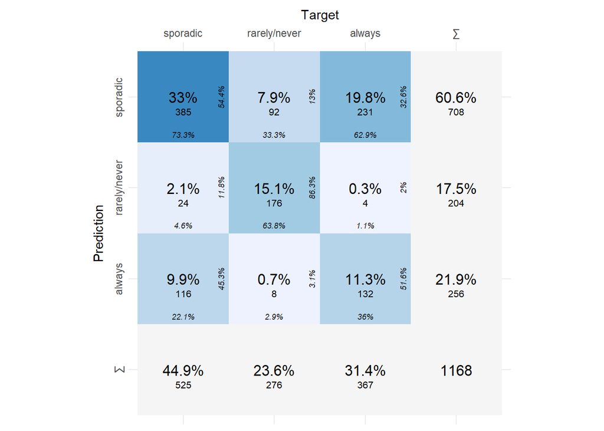

```r
reducedOLR2 <- polr(voter_category ~ educ + income_cat + race + gender + ppage + weight + Q2_1 + Q2_2 + Q2_3 + Q2_3 + Q2_5 + Q2_6 + Q2_7 + Q2_8 + Q2_9 + Q2_10 + Q3_3 + Q3_4 + Q3_5 + Q3_6 + Q4_4 + Q4_5 + Q4_6 + Q5 + Q6 + Q7 + Q8_2 + Q8_3 + Q8_4 + Q8_5 + Q8_9 + Q9_1 + Q9_2 + Q9_4 + Q10_1 + Q10_2 + Q10_3 + Q10_4 + Q11_1 + Q11_2 + Q11_3 + Q11_4 + Q11_5 + Q11_6 + Q15 + Q16 + Q17_2 + Q17_4 + Q18_1 + Q18_2 + Q18_3 + Q18_4 + Q18_5 + Q18_6 + Q18_7 + Q18_8 + Q18_10 + Q20 + Q21 + Q24 + Q25 + Q26 , data = voteTraining, Hess = TRUE)

#Removed: Q17_1, Q9_3, Q8_1, Q4_1, Q30, Q8_8, Q8_7, Q3_2, Q4_3, Q14, Q2_4

predictVoteReduced2 = predict(reducedOLR2, voteTesting)

predReduced2_df <- tibble("target" = voteTesting$voter_category, "prediction" = predictVoteReduced2)

reduced2_conf_mat <- confusion_matrix(targets = predReduced2_df$target, predictions = predReduced2_df$prediction)
plot_confusion_matrix(reduced2_conf_mat$'Confusion Matrix'[[1]], add_sums = TRUE)
```

```r
confusionMatrix(predReduced2_df$prediction, predReduced2_df$target)
```

```
## Confusion Matrix and Statistics
##
##               Reference
## Prediction     rarely/never sporadic always
##   rarely/never          176       24      4
##   sporadic               92      385    231
##   always                  8      116    132
##
## Overall Statistics
##
##                Accuracy : 0.5933
##                  95% CI : (0.5645, 0.6217)
##     No Information Rate : 0.4495
##     P-Value [Acc > NIR] : < 2.2e-16
##
##                   Kappa : 0.3413
##
##  Mcnemar's Test P-Value : < 2.2e-16
##
## Statistics by Class:
##
##                      Class: rarely/never Class: sporadic Class: always
## Sensitivity                       0.6377          0.7333        0.3597
## Specificity                       0.9686          0.4977        0.8452
## Pos Pred Value                    0.8627          0.5438        0.5156
## Neg Pred Value                    0.8963          0.6957        0.7423
## Prevalence                        0.2363          0.4495        0.3142
## Detection Rate                    0.1507          0.3296        0.1130
## Detection Prevalence              0.1747          0.6062        0.2192
## Balanced Accuracy                 0.8031          0.6155        0.6024
```

```r
vif(reducedOLR2)
```

```
##                GVIF Df GVIF^(1/(2*Df))
## educ       2.618402  2        1.272064
## income_cat 2.099968  3        1.131624
## race       2.386685  3        1.156021
## gender     1.355683  1        1.164338
## ppage      2.129185  1        1.459173
## weight     2.905489  1        1.704550
## Q2_1       3.895209  4        1.185267
## Q2_2       2.377504  4        1.114333
## Q2_3       2.917920  4        1.143231
## Q2_5       2.520095  4        1.122476
## Q2_6       3.603832  4        1.173804
## Q2_7       3.278481  4        1.160003
## Q2_8       1.916455  4        1.084707
## Q2_9       2.988488  4        1.146651
## Q2_10      2.596572  4        1.126679
## Q3_3       4.118320  4        1.193548
## Q3_4       4.390754  4        1.203143
## Q3_5       3.464657  4        1.168040
## Q3_6       3.856640  4        1.183794
## Q4_4       4.146278  4        1.194558
## Q4_5       4.443195  4        1.204930
## Q4_6       4.652589  4        1.211886
## Q5         1.934474  2        1.179345
## Q6         2.326111  4        1.111294
## Q7         1.812503  2        1.160298
## Q8_2       4.097238  4        1.192783
## Q8_3       3.727908  4        1.178781
## Q8_4       4.941737  4        1.221054
## Q8_5       4.042103  4        1.190765
## Q8_9       3.361473  4        1.163633
## Q9_1       3.738479  4        1.179198
## Q9_2       4.367695  4        1.202352
## Q9_4       4.156509  4        1.194926
## Q10_1      4.521575  2        1.458218
## Q10_2      3.132601  2        1.330382
## Q10_3      2.845571  2        1.298800
## Q10_4      2.853174  2        1.299667
## Q11_1      2.276287  2        1.228306
## Q11_2      1.805031  2        1.159101
## Q11_3      2.876348  2        1.302298
## Q11_4      3.322052  2        1.350055
## Q11_5      2.442627  2        1.250156
## Q11_6      2.180758  2        1.215211
## Q15        3.322476  5        1.127577
## Q16        3.239313  4        1.158261
## Q17_2      3.518621  4        1.170298
## Q17_4      4.167501  4        1.195321
## Q18_1      4.048496  2        1.418481
## Q18_2      3.334776  2        1.351346
## Q18_3      4.292897  2        1.439420
## Q18_4      3.940822  2        1.408954
## Q18_5      3.387973  2        1.356704
## Q18_6      3.948569  2        1.409646
## Q18_7      2.924252  2        1.307687
## Q18_8      3.278286  2        1.345587
## Q18_10     3.747490  2        1.391346
## Q20        2.334980  2        1.236149
## Q21        2.553191  3        1.169088
## Q24        3.466076  4        1.168099
## Q25        4.402421  4        1.203543
## Q26        4.910879  4        1.220099
```

```r
anova(reducedOLR2, reducedOLR)
```

```
## Likelihood ratio tests of ordinal regression models
##
## Response: voter_category
##                                                                                                                                                                                                                                                                                                          …
## 1                                                                                   educ + income_cat + race + gender + ppage + weight + Q2_1 + Q2_2 + Q2_3 + Q2_3 + Q2_5 + Q2_6 + Q2_7 + Q2_8 + Q2_9 + Q2_10 + Q3_3 + Q3_4 + Q3_5 + Q3_6 + Q4_4 + Q4_5 + Q4_6 + Q5 + Q6 + Q7 + Q8_2 + Q8_3 + Q8_4 + Q8_5…
## 2 educ + income_cat + race + gender + ppage + weight + Q2_1 + Q2_2 + Q2_3 + Q2_3 + Q2_4 + Q2_5 + Q2_6 + Q2_7 + Q2_8 + Q2_9 + Q2_10 + Q3_2 + Q3_3 + Q3_4 + Q3_5 + Q3_6 + Q4_1 + Q4_3 + Q4_4 + Q4_5 + Q4_6 + Q5 + Q6 + Q7 + Q8_1 + Q8_2 + Q8_3 + Q8_4 + Q8_5 + Q8_7 + Q8_8 + Q8_9 + Q9_1 + Q9_2 + Q9_3 + Q9…
##   Resid. df Resid. Dev   Test    Df LR stat.     Pr(Chi)
## 1      4479   7448.552
## 2      4433   7370.182 1 vs 2    46  78.3707 0.002052143
```

The second reduced model saw a decrease in accuracy among the always and never/rarely categories, and a slight increase of accuracy among the sporadic category. Tho overall accuracy rate also did not change much. The ANOVA test confirms this, showing that the removed variables are statistically signficant with a p value of 0.002.

### 2c: Conclusions

The first reduced model was the best, as by the methods used was the most accurate without eliminating variables that were considered significant by the ANOVA tests. This model correctly prediced sporadic voters 71.6% of the time, nonvoters 64.1 % of the time, and participant that always vote 37.9% of the time. Collectively, the overall accuracy rate was 59.25%, which was much better than the basic model.

## Final conclusion

In the basic set of predictors, every single one was somewhat significant in predicting a participants voter category. In particular, having an income of $40k or less and a high school education or less was the strongest indicator of voter category. The graphical observations were also confirmed by ANOVA tests. The basic model was 48.97% accurate, which while being better than picking categories at random or picking the sporadic category every time left a lot to be desired. In particular, the model was no better at predicting the never/rarely or always category than selecting one at random. The worst case scenario rate wasn’t terrible, which demonstrated that the model had issues differentiating between sporadic and the other two categories individually.

In the full data set, having little trust in government was generally associated with non-voters, though the “No Response” level was a much stronger indicator. These results were also observed among experiencing barriers of entry to voting with every variable in this category having some sort of statistical significance. For sake of time and simplicity, creating graphics and their associated ANOVA tests were left out for the rest of the full set. The full set included 79 predictor variables. An ordinal logistic model was fitted on the full set of predictors, greatly improving on the basic model’s results. As collinearity was indicated by variance inflation factors, a two reduced models were created using a backwards elimination technique with cutoffs at VIF values of 5 and 10. The model wit a cutoff of 10 had the best results, as it was the simplest of the three full set models that did not loose any significant variables. The final overall accuracy rate was 59.25%.

This project has shown that their are an absolutely massive number of factors that are associated with an individuals voting preferences. Age, education level, income, party affiliation, trust in government, and recent life events (such as losing a job or being diagnosed with COVID19) were all associated with a change in the distribution of voter category.

In the future, I would like to perform examinations and create graphics for all of the predictors, in addition to performing ANOVA and pair-wise comparisons to determine which are significant and the most influential. These results would be used to eliminate any non-significant predictors, and gain more insight to the psychology of voters. I would also like to learn and apply a few different model selection methods such as LASSO, AIC, or some sort of factor analysis to narrow down which variables are the most important, and build a more accurate model.